# BRCA 1/2 Missense Analyses

Tanya L. Hoskin, Steven N. Hart, PhD

April 20, 2017

## Necessary packages

```r
library(knitr)
library("OptimalCutpoints")
library("randomForest")
library("ROCR")
library('e1071')
library('ggplot2')
library('gridExtra')
```

Read in the data sets and create subsets

```r
#################################################
# Change file path as appropriate before running#
#################################################

brca2 <- read.csv("./sources/brca2_final.tsv",header=T,sep="\t")
brca1 <- read.csv("./sources/brca1_final.tsv",header=T,sep="\t")

previous_reports <- rbind(brca2,brca1)
table(previous_reports$CAVA_GENE,previous_reports$HDR_Classification)
```

```
##
##         Deleterious Intermediate Neutral
##   BRCA2          71           21     115
##   BRCA1          61           21     166
```

```r
brca2$Reported<-NULL
brca1$Reported<-NULL
#Make a version of data with no missings on models for randomForest()
vus.brca2 <- subset(brca2,!is.na(brca2$MutationassessorScore))
vus.brca1 <- subset(brca1,(!is.na(brca1$MutationassessorScore)&!is.na(brca1$a_gvgd_prior)))

#All BRCA1/2 variants without functional data
all2 <- read.csv("./sources/brca2_other.csv")
all2$Reported <- NULL
all1 <- read.csv("./sources/brca1_other.csv")
all1$Reported <- NULL
```

Code binary variables to report model performance at published cutpoints

```r
stack <- rbind(brca2,brca1)
stack$fathmmrank_pred         <- ifelse(stack$FathmmConvertedRankscore>0.8133,1,0)
stack$fathmm_pred             <- ifelse(stack$FathmmScore<(1.5*-1),1,0)
stack$metalrrank_pred         <- ifelse(stack$MetalrRankscore>0.8111,1,0)
stack$metalrscore_pred        <- ifelse(stack$MetalrScore>0.5,1,0)
stack$metasvmrank_pred        <- ifelse(stack$MetasvmRankscore>0.8227,1,0)
stack$metasvmscore_pred       <- ifelse(stack$MetasvmScore>0,1,0)
stack$mutationtaster_pred     <- ifelse(stack$MutationtasterScore>0.5,1,0)
stack$mutationtasterrank_pred <- ifelse(stack$MutationtasterConvertedRankscore>0.3171,1,0)
stack$pp2hdivrank_pred        <- ifelse(stack$Polyphen2HdivRankscore>0.3428,1,0)
stack$pp2hdiv_pred            <- ifelse(stack$Polyphen2HdivScore>0.453,1,0)
stack$pp2hvarrank_pred        <- ifelse(stack$Polyphen2HvarRankscore>0.442,1,0)
stack$pp2hvar_pred            <- ifelse(stack$Polyphen2HvarScore>0.447,1,0)
stack$proveanrank_pred        <- ifelse(stack$ProveanConvertedRankscore>0.543,1,0)
stack$provean_pred            <- ifelse(stack$ProveanScore<(2.5*-1),1,0)
stack$siftrank_pred           <- ifelse(stack$SiftConvertedRankscore>0.395,1,0)
stack$sift_pred               <- ifelse(stack$SiftScore<0.05,1,0)

brca2.pub <- subset(stack,X_CHROM=="13")
brca1.pub <- subset(stack,X_CHROM=="17")
```

# Table S3

### Performance characteristics of commonly used software with default thresholds

```r
options(digits=3)

sensspec <- function (pred,out){
  t <- table(pred,out,useNA="no")
  m2 <- margin.table(t,2)
  tp <- t[2,2]
  tn <- t[1,1]
  nd <- m2[2]
  nh <- m2[1]
  fn <- nd - tp
  fp <- nh - tn
  sens <- tp/nd
  spec <- tn/nh
  mcc <- (tp*tn-fp*fn)/sqrt((tp+fp)*(tp+fn)*(tn+fp)*(tn+fn))
  est <- cbind(tn,fn,fp,tp,sens,spec,mcc)
}

supp3names <- c("FathmmConvertedRankscore",
                  "FathmmScore",
                  "MetalrRankscore",
                  "MetalrScore",
                  "MetasvmRankscore",
                  "MetasvmScore",
                  "MutationtasterConvertedRankscore",
                  "MutationtasterScore",
                  "Polyphen2HdivRankscore",
                  "Polyphen2HdivScore",
                  "Polyphen2HvarRankscore",
                  "Polyphen2HvarScore",
                  "ProveanConvertedRankscore",
                  "ProveanScore",
                  "SiftConvertedRankscore",
                  "SiftScore")

supp3.names <- matrix(supp3names,nrow=length(supp3names),ncol=1)

e1.1  <- sensspec(brca1.pub$fathmmrank_pred,brca1.pub$hdr_del)
e1.2  <- sensspec(brca1.pub$fathmm_pred,brca1.pub$hdr_del)
e1.3  <- sensspec(brca1.pub$metalrrank_pred,brca1.pub$hdr_del)
e1.4  <- sensspec(brca1.pub$metalrscore_pred,brca1.pub$hdr_del)
e1.5  <- sensspec(brca1.pub$metasvmrank_pred,brca1.pub$hdr_del)
e1.6  <- sensspec(brca1.pub$metasvmscore_pred,brca1.pub$hdr_del)
e1.7  <- sensspec(brca1.pub$mutationtasterrank_pred,brca1.pub$hdr_del)
e1.8  <- sensspec(brca1.pub$mutationtaster_pred,brca1.pub$hdr_del)
e1.9  <- sensspec(brca1.pub$pp2hdivrank_pred,brca1.pub$hdr_del)
e1.10 <- sensspec(brca1.pub$pp2hdiv_pred,brca1.pub$hdr_del)
e1.11 <- sensspec(brca1.pub$pp2hvarrank_pred,brca1.pub$hdr_del)
e1.12 <- sensspec(brca1.pub$pp2hvar_pred,brca1.pub$hdr_del)
e1.13 <- sensspec(brca1.pub$proveanrank_pred,brca1.pub$hdr_del)
e1.14 <- sensspec(brca1.pub$provean_pred,brca1.pub$hdr_del)
e1.15 <- sensspec(brca1.pub$siftrank_pred,brca1.pub$hdr_del)
e1.16 <- sensspec(brca1.pub$sift_pred,brca1.pub$hdr_del)

brca1.published <- rbind(e1.1,e1.2,e1.3,e1.4,e1.5,e1.6,e1.7,e1.8,
                         e1.9,e1.10,e1.11,e1.12,e1.13,e1.14,e1.15,e1.16)

brca1.published. <- data.frame(supp3.names,brca1.published)

e2.1  <- sensspec(brca2.pub$fathmmrank_pred,brca2.pub$hdr_del)
e2.2  <- sensspec(brca2.pub$fathmm_pred,brca2.pub$hdr_del)
e2.3  <- sensspec(brca2.pub$metalrrank_pred,brca2.pub$hdr_del)
e2.4  <- sensspec(brca2.pub$metalrscore_pred,brca2.pub$hdr_del)
e2.5  <- sensspec(brca2.pub$metasvmrank_pred,brca2.pub$hdr_del)
e2.6  <- sensspec(brca2.pub$metasvmscore_pred,brca2.pub$hdr_del)
e2.7  <- sensspec(brca2.pub$mutationtasterrank_pred,brca2.pub$hdr_del)
e2.8  <- sensspec(brca2.pub$mutationtaster_pred,brca2.pub$hdr_del)
e2.9  <- sensspec(brca2.pub$pp2hdivrank_pred,brca2.pub$hdr_del)
e2.10 <- sensspec(brca2.pub$pp2hdiv_pred,brca2.pub$hdr_del)
e2.11 <- sensspec(brca2.pub$pp2hvarrank_pred,brca2.pub$hdr_del)
e2.12 <- sensspec(brca2.pub$pp2hvar_pred,brca2.pub$hdr_del)
e2.13 <- sensspec(brca2.pub$proveanrank_pred,brca2.pub$hdr_del)
e2.14 <- sensspec(brca2.pub$provean_pred,brca2.pub$hdr_del)
e2.15 <- sensspec(brca2.pub$siftrank_pred,brca2.pub$hdr_del)
e2.16 <- sensspec(brca2.pub$sift_pred,brca2.pub$hdr_del)

brca2.published <- rbind(e2.1,e2.2,e2.3,e2.4,e2.5,e2.6,e2.7,e2.8,
                         e2.9,e2.10,e2.11,e2.12,e2.13,e2.14,e2.15,e2.16)

brca2.published. <- data.frame(supp3.names,brca2.published)

supp_table3 <- rbind(brca1.published.,brca2.published.)
```

For BRCA2

```r
# BRCA2
brca2.published.$Gene="BRCA2"
ST3 <- rbind(ST3,brca2.published.)
### Add default thresholds
ST3$cutoff<-1
ST3$cutoff[which(ST3$supp3.names=="FathmmConvertedRankscore")] <- 0.8133
ST3$cutoff[which(ST3$supp3.names=="MetalrRankscore")] <- 0.8111
ST3$cutoff[which(ST3$supp3.names=="MetalrScore")] <- 0.5
ST3$cutoff[which(ST3$supp3.names=="MetasvmRankscore")] <- 0.8227
ST3$cutoff[which(ST3$supp3.names=="MetasvmScore")] <- 0
ST3$cutoff[which(ST3$supp3.names=="MutationtasterScore")] <- 0.5
ST3$cutoff[which(ST3$supp3.names=="MutationtasterConvertedRankscore") ]<- 0.3171
ST3$cutoff[which(ST3$supp3.names=="Polyphen2HdivRankscore")] <- 0.3428
ST3$cutoff[which(ST3$supp3.names=="Polyphen2HdivScore")] <- 0.453
ST3$cutoff[which(ST3$supp3.names=="Polyphen2HvarRankscore")] <- 0.442
ST3$cutoff[which(ST3$supp3.names=="Polyphen2HvarScore")] <- 0.447
ST3$cutoff[which(ST3$supp3.names=="ProveanConvertedRankscore")] <- 0.543
ST3$cutoff[which(ST3$supp3.names=="SiftConvertedRankscore")] <- 0.395
ST3$cutoff[which(ST3$supp3.names=="SiftScore")] <- 0.05
ST3$cutoff[which(ST3$supp3.names=="FathmmScore")] <- (1.5*-1)
ST3$cutoff[which(ST3$supp3.names=="ProveanScore")] <- (2.5*-1)



write.table(file="tables/Table_S3.tsv",ST3,row.names = F,sep="\t")
kable(ST3)
```

[output not shown]

| supp3.names | tn | fn | fp | tp | sens | spec | mcc | Gene | cutoff |
| --- | --- | --- | --- | --- | --- | --- | --- | --- | --- |
| FathmmConvertedRankscore | 30 | 8 | 147 | 51 | 0.864 | 0.169 | 0.040 | BRCA1 | 0.813 |
| FathmmScore | 30 | 8 | 147 | 51 | 0.864 | 0.169 | 0.040 | BRCA1 | -1.500 |
| MetalrRankscore | 82 | 1 | 95 | 58 | 0.983 | 0.463 | 0.405 | BRCA1 | 0.811 |
| MetalrScore | 82 | 1 | 95 | 58 | 0.983 | 0.463 | 0.405 | BRCA1 | 0.500 |
| MetasvmRankscore | 118 | 2 | 59 | 57 | 0.966 | 0.667 | 0.548 | BRCA1 | 0.823 |
| MetasvmScore | 118 | 2 | 59 | 57 | 0.966 | 0.667 | 0.548 | BRCA1 | 0.000 |
| MutationtasterConvertedRankscore | 82 | 0 | 95 | 59 | 1.000 | 0.463 | 0.421 | BRCA1 | 0.317 |
| MutationtasterScore | 1 | 0 | 176 | 59 | 1.000 | 0.006 | 0.038 | BRCA1 | 0.500 |
| Polyphen2HdivRankscore | 48 | 0 | 129 | 59 | 1.000 | 0.271 | 0.292 | BRCA1 | 0.343 |
| Polyphen2HdivScore | 48 | 0 | 129 | 59 | 1.000 | 0.271 | 0.292 | BRCA1 | 0.453 |
| Polyphen2HvarRankscore | 64 | 0 | 113 | 59 | 1.000 | 0.362 | 0.352 | BRCA1 | 0.442 |
| Polyphen2HvarScore | 64 | 0 | 113 | 59 | 1.000 | 0.362 | 0.352 | BRCA1 | 0.447 |
| ProveanConvertedRankscore | 95 | 3 | 82 | 56 | 0.949 | 0.537 | 0.427 | BRCA1 | 0.543 |
| ProveanScore | 177 | 58 | 0 | 1 | 0.017 | 1.000 | 0.113 | BRCA1 | -2.500 |
| SiftConvertedRankscore | 50 | 1 | 127 | 58 | 0.983 | 0.282 | 0.279 | BRCA1 | 0.395 |
| SiftScore | 50 | 1 | 127 | 58 | 0.983 | 0.282 | 0.279 | BRCA1 | 0.050 |
| FathmmConvertedRankscore | 73 | 7 | 63 | 64 | 0.901 | 0.537 | 0.427 | BRCA2 | 0.813 |
| FathmmScore | 73 | 7 | 63 | 64 | 0.901 | 0.537 | 0.427 | BRCA2 | -1.500 |
| MetalrRankscore | 49 | 1 | 87 | 70 | 0.986 | 0.360 | 0.384 | BRCA2 | 0.811 |
| MetalrScore | 49 | 1 | 87 | 70 | 0.986 | 0.360 | 0.384 | BRCA2 | 0.500 |
| MetasvmRankscore | 53 | 1 | 83 | 70 | 0.986 | 0.390 | 0.406 | BRCA2 | 0.823 |
| MetasvmScore | 53 | 1 | 83 | 70 | 0.986 | 0.390 | 0.406 | BRCA2 | 0.000 |
| MutationtasterConvertedRankscore | 32 | 1 | 104 | 70 | 0.986 | 0.235 | 0.287 | BRCA2 | 0.317 |
| MutationtasterScore | 1 | 0 | 135 | 71 | 1.000 | 0.007 | 0.050 | BRCA2 | 0.500 |
| Polyphen2HdivRankscore | 16 | 1 | 119 | 70 | 0.986 | 0.119 | 0.180 | BRCA2 | 0.343 |
| Polyphen2HdivScore | 16 | 1 | 119 | 70 | 0.986 | 0.119 | 0.180 | BRCA2 | 0.453 |
| Polyphen2HvarRankscore | 30 | 1 | 105 | 70 | 0.986 | 0.222 | 0.277 | BRCA2 | 0.442 |
| Polyphen2HvarScore | 30 | 1 | 105 | 70 | 0.986 | 0.222 | 0.277 | BRCA2 | 0.447 |
| ProveanConvertedRankscore | 126 | 60 | 10 | 11 | 0.155 | 0.926 | 0.128 | BRCA2 | 0.543 |
| ProveanScore | 126 | 60 | 10 | 11 | 0.155 | 0.926 | 0.128 | BRCA2 | -2.500 |
| SiftConvertedRankscore | 27 | 0 | 109 | 71 | 1.000 | 0.199 | 0.280 | BRCA2 | 0.395 |
| SiftScore | 27 | 0 | 109 | 71 | 1.000 | 0.199 | 0.280 | BRCA2 | 0.050 |

The Making of supplemental Table 4 for existing models BRCA2, Scenario 1

```r
#For these models, higher scores are worse
varnames1 <-
  c("a_gvgd_prior","CaddPhred","CaddRaw","CaddRawRankscore",
              "CAROL_score","Condel_score","DannRankscore","DannScore",
              "FathmmConvertedRankscore","GerpNr","GerpRs",
              "GerpRsRankscore","LrtConvertedRankscore","MetalrRankscore",
              "MetalrScore","MetasvmRankscore","MetasvmScore","MutationassessorRankscore",
              "MutationassessorScore","MutationtasterConvertedRankscore",
              "MutationtasterScore","PERCH","PERCH_noMAF","Phastcons20wayMammalianRankscore",
              "Phastcons7wayVertebrateRankscore","Phylop20wayMammalianRankscore",
              "Phylop7wayVertebrateRankscore","Polyphen2HdivRankscore","Polyphen2HdivScore",
              "Polyphen2HvarRankscore","Polyphen2HvarScore","ProveanConvertedRankscore",
              "SiftConvertedRankscore","Siphy29wayLogoddsRankscore",
              "Vest3Rankscore","Vest3Score")

# For these models, lower scores are worse
varnames2 <- c("FathmmScore","LrtScore","ProveanScore","SiftScore")

# These models have two optimal cutpoints by SpEqualSe criterion for one or both genes
# Special handling outside loop b/c structure of optimal.cutpoints output list is different
varnames3 <- c("FathmmConvertedRankscore","FathmmScore","LrtConvertedRankscore",
               "LrtScore","ProveanScore","DannScore","CaddRaw","CaddRawRankscore")

# BRCA2 Variants
# Outcome = Deleterious vs Intermediate/Neutral
# Find optimal cutpoint for each model

fn <- matrix(NA,nrow=length(varnames1),ncol=1)
fp <- matrix(NA,nrow=length(varnames1),ncol=1)
nh <- matrix(NA,nrow=length(varnames1),ncol=1)
nd <- matrix(NA,nrow=length(varnames1),ncol=1)
tp <- matrix(NA,nrow=length(varnames1),ncol=1)
tn <- matrix(NA,nrow=length(varnames1),ncol=1)
mcc <- matrix(NA,nrow=length(varnames1),ncol=1)
cutoff <- matrix(NA,nrow=length(varnames1),ncol=1)
auc <- matrix(NA,nrow=length(varnames1),ncol=3)
sens <- matrix(NA,nrow=length(varnames1),ncol=3)
spec <- matrix(NA,nrow=length(varnames1),ncol=3)

for (i in 1:length(varnames1)) {

v2a.i <- optimal.cutpoints(X=varnames1[i],status="hdr_del",
                            tag.healthy=0,methods=c("SpEqualSe"),
                                      control = control.cutpoints(ci.SeSp = "AgrestiCoull"),
                                      ci.fit=TRUE,data=brca2)

auc[i,] <- v2a.i$SpEqualSe[[1]]$measures.acc$AUC
sens[i,] <- v2a.i$SpEqualSe[[1]]$optimal.cutoff$Se[c(1:3)]
spec[i,] <- v2a.i$SpEqualSe[[1]]$optimal.cutoff$Sp[c(1:3)]
fn[i,1] <- v2a.i$SpEqualSe[[1]]$optimal.cutoff$FN[1]
fp[i,1] <- v2a.i$SpEqualSe[[1]]$optimal.cutoff$FP[1]
nh[i,1] <- v2a.i$SpEqualSe[[1]]$measures.acc$n$h
nd[i,1] <- v2a.i$SpEqualSe[[1]]$measures.acc$n$d
tp[i,1] <- nd[i,] - fn[i,]
tn[i,1] <- nh[i,] - fp[i,]

cutoff[i,1] <- v2a.i$SpEqualSe[[1]]$optimal.cutoff$cutoff

mcc[i,1] <- (tp[i,]*tn[i,]-fp[i,]*fn[i,])/sqrt((tp[i,]+fp[i,])*
            (tp[i,]+fn[i,])*(tn[i,]+fp[i,])*(tn[i,]+fn[i,]))

brca2a.models.dir1 <- data.frame(varnames1,cutoff,sens,spec,auc,fn,fp,tp,tn,mcc,stringsAsFactors = FALSE)
colnames(brca2a.models.dir1) <- c("model","cutpoint","sens","sens.lcl","sens.ucl","spec",
                                  "spec.lcl","spec.ucl","auc","auc.lcl","auc.ucl","FN","FP",
                                  "TP","TN","mcc")

}

fn <- matrix(NA,nrow=4,ncol=1)
fp <- matrix(NA,nrow=4,ncol=1)
nh <- matrix(NA,nrow=4,ncol=1)
nd <- matrix(NA,nrow=4,ncol=1)
tp <- matrix(NA,nrow=4,ncol=1)
tn <- matrix(NA,nrow=4,ncol=1)
mcc <- matrix(NA,nrow=4,ncol=1)
cutoff <- matrix(NA,nrow=4,ncol=1)
auc <- matrix(NA,nrow=4,ncol=3)
sens <- matrix(NA,nrow=4,ncol=3)
spec <- matrix(NA,nrow=4,ncol=3)

for (i in 1:length(varnames2)) {

v2a.i <- optimal.cutpoints(X=varnames2[i],status="hdr_del",direction=">",
                            tag.healthy=0,methods=c("SpEqualSe"),
                                      control = control.cutpoints(ci.SeSp = "AgrestiCoull"),
                                      ci.fit=TRUE,data=brca2)

auc[i,] <- v2a.i$SpEqualSe[[1]]$measures.acc$AUC
sens[i,] <- v2a.i$SpEqualSe[[1]]$optimal.cutoff$Se[c(1:3)]
spec[i,] <- v2a.i$SpEqualSe[[1]]$optimal.cutoff$Sp[c(1:3)]
fn[i,1] <- v2a.i$SpEqualSe[[1]]$optimal.cutoff$FN[1]
fp[i,1] <- v2a.i$SpEqualSe[[1]]$optimal.cutoff$FP[1]
nh[i,1] <- v2a.i$SpEqualSe[[1]]$measures.acc$n$h
nd[i,1] <- v2a.i$SpEqualSe[[1]]$measures.acc$n$d
tp[i,1] <- nd[i,] - fn[i,]
tn[i,1] <- nh[i,] - fp[i,]


cutoff[i,1] <- v2a.i$SpEqualSe[[1]]$optimal.cutoff$cutoff

mcc[i,1] <- (tp[i,]*tn[i,]-fp[i,]*fn[i,])/sqrt((tp[i,]+fp[i,])*
                                                 (tp[i,]+fn[i,])*(tn[i,]+fp[i,])*(tn[i,]+fn[i,]))

brca2a.models.dir2 <- data.frame(varnames2,cutoff,sens,spec,auc,fn,fp,tp,tn,mcc,stringsAsFactors = FALSE)
colnames(brca2a.models.dir2) <- c("model","cutpoint","sens","sens.lcl","sens.ucl","spec",
                                  "spec.lcl","spec.ucl","auc","auc.lcl","auc.ucl","FN","FP",
                                  "TP","TN","mcc")
}

brca2a.models <- rbind(brca2a.models.dir1,brca2a.models.dir2)
brca2a.models. <- brca2a.models[order(brca2a.models$model),]
brca2a.auc <- brca2a.models[,c("model","auc","auc.lcl","auc.ucl")]
brca2a.auc. <- brca2a.auc[order(brca2a.auc$model),]

ST4_BRCA2_S1 <-brca2a.models.
ST4_BRCA2_S1$Gene="BRCA2"
ST4_BRCA2_S1$Scenario=1
```

BRCA1 Scenario 1

```r
# BRCA1 Variants
# Outcome = Deleterious vs Intermediate/Neutral
# Find optimal cutpoint for each model
#These have one optimal cutpoint & higher is worse for BRCA1 Scenario1
varnames1. <- c("a_gvgd_prior","CaddPhred","CaddRaw","CaddRawRankscore",
                "CAROL_score","Condel_score","DannRankscore","DannScore",
                "GerpNr","GerpRs",
                "GerpRsRankscore","MetalrRankscore",
                "MetalrScore","MetasvmRankscore","MetasvmScore","MutationassessorRankscore",
                "MutationassessorScore","MutationtasterConvertedRankscore",
                "MutationtasterScore","PERCH","PERCH_noMAF","Phastcons20wayMammalianRankscore",
                "Phastcons7wayVertebrateRankscore","Phylop20wayMammalianRankscore",
                "Phylop7wayVertebrateRankscore","Polyphen2HdivRankscore","Polyphen2HdivScore",
                "Polyphen2HvarRankscore","Polyphen2HvarScore","ProveanConvertedRankscore",
                "SiftConvertedRankscore","Siphy29wayLogoddsRankscore",
                "Vest3Rankscore","Vest3Score")

#These have one optimal cutpoint & lower is worse for BRCA1 Scenario1
varnames2. <- c("SiftScore")

#These have two optimal cutpoints, pick one, direction = higher worse
varnames3a. <- c("FathmmConvertedRankscore","LrtConvertedRankscore")

#These have two optimal cutpoints, pick one, direction = lower worse
varnames3b. <- c("FathmmScore","LrtScore")
varnames3c. <- c("ProveanScore")

fn <- matrix(NA,nrow=length(varnames1.),ncol=1)
fp <- matrix(NA,nrow=length(varnames1.),ncol=1)
nh <- matrix(NA,nrow=length(varnames1.),ncol=1)
nd <- matrix(NA,nrow=length(varnames1.),ncol=1)
tp <- matrix(NA,nrow=length(varnames1.),ncol=1)
tn <- matrix(NA,nrow=length(varnames1.),ncol=1)
mcc <- matrix(NA,nrow=length(varnames1.),ncol=1)
cutoff <- matrix(NA,nrow=length(varnames1.),ncol=1)
auc <- matrix(NA,nrow=length(varnames1.),ncol=3)
sens <- matrix(NA,nrow=length(varnames1.),ncol=3)
spec <- matrix(NA,nrow=length(varnames1.),ncol=3)

for (i in 1:length(varnames1.)) {

v1a.i <- optimal.cutpoints(X=varnames1.[i],status="hdr_del",
                           tag.healthy=0,methods=c("SpEqualSe"),
                                     control = control.cutpoints(ci.SeSp = "AgrestiCoull"),
                                     ci.fit=TRUE,data=brca1)

auc[i,] <- v1a.i$SpEqualSe[[1]]$measures.acc$AUC
sens[i,] <- v1a.i$SpEqualSe[[1]]$optimal.cutoff$Se[c(1:3)]
spec[i,] <- v1a.i$SpEqualSe[[1]]$optimal.cutoff$Sp[c(1:3)]
fn[i,1] <- v1a.i$SpEqualSe[[1]]$optimal.cutoff$FN[1]
fp[i,1] <- v1a.i$SpEqualSe[[1]]$optimal.cutoff$FP[1]
nh[i,1] <- v1a.i$SpEqualSe[[1]]$measures.acc$n$h
nd[i,1] <- v1a.i$SpEqualSe[[1]]$measures.acc$n$d
tp[i,1] <- nd[i,] - fn[i,]
tn[i,1] <- nh[i,] - fp[i,]

cutoff[i,1] <- v1a.i$SpEqualSe[[1]]$optimal.cutoff$cutoff

mcc[i,1] <- (tp[i,]*tn[i,]-fp[i,]*fn[i,])/sqrt((tp[i,]+fp[i,])*
            (tp[i,]+fn[i,])*(tn[i,]+fp[i,])*(tn[i,]+fn[i,]))

brca1a.models.dir1 <- data.frame(varnames1.,cutoff,sens,spec,auc,fn,fp,tp,tn,mcc,stringsAsFactors = FALSE)
colnames(brca1a.models.dir1) <- c("model","cutpoint","sens","sens.lcl","sens.ucl","spec",
                             "spec.lcl","spec.ucl","auc","auc.lcl","auc.ucl","FN","FP",
                             "TP","TN","mcc")

}

fn <- matrix(NA,nrow=1,ncol=1)
fp <- matrix(NA,nrow=1,ncol=1)
nh <- matrix(NA,nrow=1,ncol=1)
nd <- matrix(NA,nrow=1,ncol=1)
tp <- matrix(NA,nrow=1,ncol=1)
tn <- matrix(NA,nrow=1,ncol=1)
mcc <- matrix(NA,nrow=1,ncol=1)
cutoff <- matrix(NA,nrow=1,ncol=1)
auc <- matrix(NA,nrow=1,ncol=3)
sens <- matrix(NA,nrow=1,ncol=3)
spec <- matrix(NA,nrow=1,ncol=3)

for (i in 1:length(varnames2.)) {

v1a.i <- optimal.cutpoints(X=varnames2.[i],status="hdr_del",direction=">",
                           tag.healthy=0,methods=c("SpEqualSe"),
                                     control = control.cutpoints(ci.SeSp = "AgrestiCoull"),
                                     ci.fit=TRUE,data=brca1)

auc[i,] <- v1a.i$SpEqualSe[[1]]$measures.acc$AUC
sens[i,] <- v1a.i$SpEqualSe[[1]]$optimal.cutoff$Se[c(1:3)]
spec[i,] <- v1a.i$SpEqualSe[[1]]$optimal.cutoff$Sp[c(1:3)]
fn[i,1] <- v1a.i$SpEqualSe[[1]]$optimal.cutoff$FN[1]
fp[i,1] <- v1a.i$SpEqualSe[[1]]$optimal.cutoff$FP[1]
nh[i,1] <- v1a.i$SpEqualSe[[1]]$measures.acc$n$h
nd[i,1] <- v1a.i$SpEqualSe[[1]]$measures.acc$n$d
tp[i,1] <- nd[i,] - fn[i,]
tn[i,1] <- nh[i,] - fp[i,]

cutoff[i,1] <- v1a.i$SpEqualSe[[1]]$optimal.cutoff$cutoff

mcc[i,1] <- (tp[i,]*tn[i,]-fp[i,]*fn[i,])/sqrt((tp[i,]+fp[i,])*
                                                 (tp[i,]+fn[i,])*(tn[i,]+fp[i,])*(tn[i,]+fn[i,]))

brca1a.models.dir2 <- data.frame(varnames2.,cutoff,sens,spec,auc,fn,fp,tp,tn,mcc,stringsAsFactors = FALSE)
colnames(brca1a.models.dir2) <- c("model","cutpoint","sens","sens.lcl","sens.ucl","spec",
                                  "spec.lcl","spec.ucl","auc","auc.lcl","auc.ucl","FN","FP",
                                  "TP","TN","mcc")

}


####

fn <- matrix(NA,nrow=length(varnames3a.),ncol=1)
fp <- matrix(NA,nrow=length(varnames3a.),ncol=1)
nh <- matrix(NA,nrow=length(varnames3a.),ncol=1)
nd <- matrix(NA,nrow=length(varnames3a.),ncol=1)
tp <- matrix(NA,nrow=length(varnames3a.),ncol=1)
tn <- matrix(NA,nrow=length(varnames3a.),ncol=1)
mcc <- matrix(NA,nrow=length(varnames3a.),ncol=1)
cutoff <- matrix(NA,nrow=length(varnames3a.),ncol=1)
auc <- matrix(NA,nrow=length(varnames3a.),ncol=3)
sens <- matrix(NA,nrow=length(varnames3a.),ncol=3)
spec <- matrix(NA,nrow=length(varnames3a.),ncol=3)

for (i in 1:length(varnames3a.)) {

v1a.i <- optimal.cutpoints(X=varnames3a.[i],status="hdr_del",
                            tag.healthy=0,methods=c("SpEqualSe"),
                    control = control.cutpoints(ci.SeSp = "AgrestiCoull"),
                       ci.fit=TRUE,data=brca1)

auc[i,] <- v1a.i$SpEqualSe[[1]]$measures.acc$AUC
sens[i,] <- v1a.i$SpEqualSe[[1]]$optimal.cutoff$Se[c(1,3,5)]
spec[i,] <- v1a.i$SpEqualSe[[1]]$optimal.cutoff$Sp[c(1,3,5)]
fn[i,1] <- v1a.i$SpEqualSe[[1]]$optimal.cutoff$FN[1]
fp[i,1] <- v1a.i$SpEqualSe[[1]]$optimal.cutoff$FP[1]
nh[i,1] <- v1a.i$SpEqualSe[[1]]$measures.acc$n$h
nd[i,1] <- v1a.i$SpEqualSe[[1]]$measures.acc$n$d
tp[i,1] <- nd[i,] - fn[i,]
tn[i,1] <- nh[i,] - fp[i,]

cutoff[i,1] <- v1a.i$SpEqualSe[[1]]$optimal.cutoff$cutoff[1]

mcc[i,1] <- (tp[i,]*tn[i,]-fp[i,]*fn[i,])/sqrt((tp[i,]+fp[i,])*
            (tp[i,]+fn[i,])*(tn[i,]+fp[i,])*(tn[i,]+fn[i,]))

brca1a.models.dir1. <- data.frame(varnames3a.,cutoff,sens,spec,auc,fn,fp,tp,tn,mcc,stringsAsFactors = FALSE)
colnames(brca1a.models.dir1.) <- c("model","cutpoint","sens","sens.lcl","sens.ucl","spec",
                             "spec.lcl","spec.ucl","auc","auc.lcl","auc.ucl","FN","FP",
                             "TP","TN","mcc")

}


fn <- matrix(NA,nrow=length(varnames3b.),ncol=1)
fp <- matrix(NA,nrow=length(varnames3b.),ncol=1)
nh <- matrix(NA,nrow=length(varnames3b.),ncol=1)
nd <- matrix(NA,nrow=length(varnames3b.),ncol=1)
tp <- matrix(NA,nrow=length(varnames3b.),ncol=1)
tn <- matrix(NA,nrow=length(varnames3b.),ncol=1)
mcc <- matrix(NA,nrow=length(varnames3b.),ncol=1)
cutoff <- matrix(NA,nrow=length(varnames3b.),ncol=1)
auc <- matrix(NA,nrow=length(varnames3b.),ncol=3)
sens <- matrix(NA,nrow=length(varnames3b.),ncol=3)
spec <- matrix(NA,nrow=length(varnames3b.),ncol=3)

for (i in 1:length(varnames3b.)) {

v1a.i <- optimal.cutpoints(X=varnames3b.[i],status="hdr_del",direction=">",
                            tag.healthy=0,methods=c("SpEqualSe"),
                                      control = control.cutpoints(ci.SeSp = "AgrestiCoull"),
                                      ci.fit=TRUE,data=brca1)

auc[i,] <- v1a.i$SpEqualSe[[1]]$measures.acc$AUC
sens[i,] <- v1a.i$SpEqualSe[[1]]$optimal.cutoff$Se[c(2,4,6)]
spec[i,] <- v1a.i$SpEqualSe[[1]]$optimal.cutoff$Sp[c(2,4,6)]
fn[i,1] <- v1a.i$SpEqualSe[[1]]$optimal.cutoff$FN[2]
fp[i,1] <- v1a.i$SpEqualSe[[1]]$optimal.cutoff$FP[2]
nh[i,1] <- v1a.i$SpEqualSe[[1]]$measures.acc$n$h
nd[i,1] <- v1a.i$SpEqualSe[[1]]$measures.acc$n$d
tp[i,1] <- nd[i,] - fn[i,]
tn[i,1] <- nh[i,] - fp[i,]

cutoff[i,1] <- v1a.i$SpEqualSe[[1]]$optimal.cutoff$cutoff[2]

mcc[i,1] <- (tp[i,]*tn[i,]-fp[i,]*fn[i,])/sqrt((tp[i,]+fp[i,])*
                                                 (tp[i,]+fn[i,])*(tn[i,]+fp[i,])*(tn[i,]+fn[i,]))

brca1a.models.dir2. <- data.frame(varnames3b.,cutoff,sens,spec,auc,fn,fp,tp,tn,mcc,stringsAsFactors = FALSE)
colnames(brca1a.models.dir2.) <- c("model","cutpoint","sens","sens.lcl","sens.ucl","spec",
                                   "spec.lcl","spec.ucl","auc","auc.lcl","auc.ucl","FN","FP",
                                   "TP","TN","mcc")

}


fn <- matrix(NA,nrow=length(varnames3c.),ncol=1)
fp <- matrix(NA,nrow=length(varnames3c.),ncol=1)
nh <- matrix(NA,nrow=length(varnames3c.),ncol=1)
nd <- matrix(NA,nrow=length(varnames3c.),ncol=1)
tp <- matrix(NA,nrow=length(varnames3c.),ncol=1)
tn <- matrix(NA,nrow=length(varnames3c.),ncol=1)
mcc <- matrix(NA,nrow=length(varnames3c.),ncol=1)
cutoff <- matrix(NA,nrow=length(varnames3c.),ncol=1)
auc <- matrix(NA,nrow=length(varnames3c.),ncol=3)
sens <- matrix(NA,nrow=length(varnames3c.),ncol=3)
spec <- matrix(NA,nrow=length(varnames3c.),ncol=3)

for (i in 1:length(varnames3c.)) {

v1a.i <- optimal.cutpoints(X=varnames3c.[i],status="hdr_del",direction=">",
                            tag.healthy=0,methods=c("SpEqualSe"),
                                      control = control.cutpoints(ci.SeSp = "AgrestiCoull"),
                                      ci.fit=TRUE,data=brca1)

auc[i,] <- v1a.i$SpEqualSe[[1]]$measures.acc$AUC
sens[i,] <- v1a.i$SpEqualSe[[1]]$optimal.cutoff$Se[c(1,3,5)]
spec[i,] <- v1a.i$SpEqualSe[[1]]$optimal.cutoff$Sp[c(1,3,5)]
fn[i,1] <- v1a.i$SpEqualSe[[1]]$optimal.cutoff$FN[1]
fp[i,1] <- v1a.i$SpEqualSe[[1]]$optimal.cutoff$FP[1]
nh[i,1] <- v1a.i$SpEqualSe[[1]]$measures.acc$n$h
nd[i,1] <- v1a.i$SpEqualSe[[1]]$measures.acc$n$d
tp[i,1] <- nd[i,] - fn[i,]
tn[i,1] <- nh[i,] - fp[i,]

cutoff[i,1] <- v1a.i$SpEqualSe[[1]]$optimal.cutoff$cutoff[1]

mcc[i,1] <- (tp[i,]*tn[i,]-fp[i,]*fn[i,])/sqrt((tp[i,]+fp[i,])*
                                          (tp[i,]+fn[i,])*(tn[i,]+fp[i,])*(tn[i,]+fn[i,]))

brca1a.models.dir2.. <- data.frame(varnames3c.,cutoff,sens,spec,auc,fn,fp,tp,tn,mcc,
                                   stringsAsFactors = FALSE)
colnames(brca1a.models.dir2..) <- c("model","cutpoint","sens","sens.lcl","sens.ucl","spec",
                                    "spec.lcl","spec.ucl","auc","auc.lcl","auc.ucl","FN","FP",
                                    "TP","TN","mcc")

}

brca1a.models <- rbind(brca1a.models.dir1,brca1a.models.dir2,brca1a.models.dir1.,
                        brca1a.models.dir2.,brca1a.models.dir2..)
brca1a.models. <- brca1a.models[order(brca1a.models$model),]
brca1a.auc <- brca1a.models[,c("model","auc","auc.lcl","auc.ucl")]
brca1a.auc. <- brca1a.auc[order(brca1a.auc$model),]

ST4_BRCA1_S1 <- brca1a.models.
ST4_BRCA1_S1$Gene="BRCA1"
ST4_BRCA1_S1$Scenario=1
```

BRCA1, Scenario 2

```r
# Scenario 2
# Outcome = Deleterious/Intermediate vs Neutral
# Find optimal cutpoint for each model
varnames1. <- c("a_gvgd_prior","CaddPhred","CaddRaw","CaddRawRankscore",
                "CAROL_score","Condel_score","DannRankscore","DannScore",
                "GerpNr","GerpRs",
                "GerpRsRankscore","MetalrRankscore",
                "MetalrScore","MetasvmRankscore","MetasvmScore","MutationassessorRankscore",
                "MutationassessorScore","MutationtasterConvertedRankscore",
                "MutationtasterScore","PERCH","PERCH_noMAF","Phastcons20wayMammalianRankscore",
                "Phastcons7wayVertebrateRankscore","Phylop20wayMammalianRankscore",
                "Phylop7wayVertebrateRankscore","Polyphen2HdivRankscore","Polyphen2HdivScore",
                "Polyphen2HvarRankscore","Polyphen2HvarScore","ProveanConvertedRankscore",
                "SiftConvertedRankscore","Siphy29wayLogoddsRankscore",
                "Vest3Rankscore","Vest3Score","FathmmConvertedRankscore","LrtConvertedRankscore")

#These have one optimal cutpoint & lower is worse for BRCA1 Scenario1
varnames2. <- c("SiftScore","FathmmScore","LrtScore","ProveanScore")

fn <- matrix(NA,nrow=length(varnames1.),ncol=1)
fp <- matrix(NA,nrow=length(varnames1.),ncol=1)
nh <- matrix(NA,nrow=length(varnames1.),ncol=1)
nd <- matrix(NA,nrow=length(varnames1.),ncol=1)
tp <- matrix(NA,nrow=length(varnames1.),ncol=1)
tn <- matrix(NA,nrow=length(varnames1.),ncol=1)
mcc <- matrix(NA,nrow=length(varnames1.),ncol=1)
cutoff <- matrix(NA,nrow=length(varnames1.),ncol=1)
auc <- matrix(NA,nrow=length(varnames1.),ncol=3)
sens <- matrix(NA,nrow=length(varnames1.),ncol=3)
spec <- matrix(NA,nrow=length(varnames1.),ncol=3)

for (i in 1:length(varnames1.)) {

v1b.i <- optimal.cutpoints(X=varnames1.[i],status="hdr_not_neutral",
                            tag.healthy=0,methods=c("SpEqualSe"),
                                      control = control.cutpoints(ci.SeSp = "AgrestiCoull"),
                                      ci.fit=TRUE,data=brca1)

auc[i,] <- v1b.i$SpEqualSe[[1]]$measures.acc$AUC
sens[i,] <- v1b.i$SpEqualSe[[1]]$optimal.cutoff$Se[c(1:3)]
spec[i,] <- v1b.i$SpEqualSe[[1]]$optimal.cutoff$Sp[c(1:3)]
fn[i,1] <- v1b.i$SpEqualSe[[1]]$optimal.cutoff$FN[1]
fp[i,1] <- v1b.i$SpEqualSe[[1]]$optimal.cutoff$FP[1]
nh[i,1] <- v1b.i$SpEqualSe[[1]]$measures.acc$n$h
nd[i,1] <- v1b.i$SpEqualSe[[1]]$measures.acc$n$d
tp[i,1] <- nd[i,] - fn[i,]
tn[i,1] <- nh[i,] - fp[i,]

cutoff[i,1] <- v1b.i$SpEqualSe[[1]]$optimal.cutoff$cutoff

mcc[i,1] <- (tp[i,]*tn[i,]-fp[i,]*fn[i,])/sqrt((tp[i,]+fp[i,])*
            (tp[i,]+fn[i,])*(tn[i,]+fp[i,])*(tn[i,]+fn[i,]))

brca1b.models.dir1 <- data.frame(varnames1.,cutoff,sens,spec,auc,fn,fp,tp,tn,mcc,stringsAsFactors = FALSE)
colnames(brca1b.models.dir1) <- c("model","cutpoint","sens","sens.lcl","sens.ucl","spec",
                                  "spec.lcl","spec.ucl","auc","auc.lcl","auc.ucl","FN","FP",
                                  "TP","TN","mcc")

}

fn <- matrix(NA,nrow=length(varnames2.),ncol=1)
fp <- matrix(NA,nrow=length(varnames2.),ncol=1)
nh <- matrix(NA,nrow=length(varnames2.),ncol=1)
nd <- matrix(NA,nrow=length(varnames2.),ncol=1)
tp <- matrix(NA,nrow=length(varnames2.),ncol=1)
tn <- matrix(NA,nrow=length(varnames2.),ncol=1)
mcc <- matrix(NA,nrow=length(varnames2.),ncol=1)
cutoff <- matrix(NA,nrow=length(varnames2.),ncol=1)
auc <- matrix(NA,nrow=length(varnames2.),ncol=3)
sens <- matrix(NA,nrow=length(varnames2.),ncol=3)
spec <- matrix(NA,nrow=length(varnames2.),ncol=3)

for (i in 1:length(varnames2.)) {

v1b.i <- optimal.cutpoints(X=varnames2.[i],status="hdr_not_neutral",direction=">",
                            tag.healthy=0,methods=c("SpEqualSe"),
                                      control = control.cutpoints(ci.SeSp = "AgrestiCoull"),
                                      ci.fit=TRUE,data=brca1)

auc[i,] <- v1b.i$SpEqualSe[[1]]$measures.acc$AUC
sens[i,] <- v1b.i$SpEqualSe[[1]]$optimal.cutoff$Se[c(1:3)]
spec[i,] <- v1b.i$SpEqualSe[[1]]$optimal.cutoff$Sp[c(1:3)]
fn[i,1] <- v1b.i$SpEqualSe[[1]]$optimal.cutoff$FN[1]
fp[i,1] <- v1b.i$SpEqualSe[[1]]$optimal.cutoff$FP[1]
nh[i,1] <- v1b.i$SpEqualSe[[1]]$measures.acc$n$h
nd[i,1] <- v1b.i$SpEqualSe[[1]]$measures.acc$n$d
tp[i,1] <- nd[i,] - fn[i,]
tn[i,1] <- nh[i,] - fp[i,]

cutoff[i,1] <- v1b.i$SpEqualSe[[1]]$optimal.cutoff$cutoff

mcc[i,1] <- (tp[i,]*tn[i,]-fp[i,]*fn[i,])/sqrt((tp[i,]+fp[i,])*
                                               (tp[i,]+fn[i,])*(tn[i,]+fp[i,])*(tn[i,]+fn[i,]))

brca1b.models.dir2 <- data.frame(varnames2.,cutoff,sens,spec,auc,fn,fp,tp,tn,mcc,stringsAsFactors = FALSE)
colnames(brca1b.models.dir2) <- c("model","cutpoint","sens","sens.lcl","sens.ucl","spec",
                                  "spec.lcl","spec.ucl","auc","auc.lcl","auc.ucl","FN","FP",
                                  "TP","TN","mcc")

}

brca1b.models <- rbind(brca1b.models.dir1,brca1b.models.dir2)
brca1b.models. <- brca1b.models[order(brca1b.models$model),]
brca1b.auc <- brca1b.models[,c("model","auc","auc.lcl","auc.ucl")]
brca1b.auc. <- brca1b.auc[order(brca1b.auc$model),]


ST4_BRCA1_S2 <- brca1b.models.
ST4_BRCA1_S2$Gene="BRCA1"
ST4_BRCA1_S2$Scenario=2
```

BRCA2 Scenario 2

```r
# BRCA2 Variants
# Outcome = Deleterious/Intermediate vs Neutral
# Find optimal cutpoint for each model
#These have one optimal cutpoint & higher is worse for BRCA2 Scenario2
varnames1. <- c("a_gvgd_prior","CaddPhred",
              "CAROL_score","Condel_score","DannRankscore",
              "GerpNr","GerpRs","FathmmConvertedRankscore","LrtConvertedRankscore",
              "GerpRsRankscore","MetalrRankscore",
              "MetalrScore","MetasvmRankscore","MetasvmScore","MutationassessorRankscore",
              "MutationassessorScore","MutationtasterConvertedRankscore",
              "MutationtasterScore","PERCH","PERCH_noMAF","Phastcons20wayMammalianRankscore",
              "Phastcons7wayVertebrateRankscore","Phylop20wayMammalianRankscore",
              "Phylop7wayVertebrateRankscore","Polyphen2HdivRankscore","Polyphen2HdivScore",
              "Polyphen2HvarRankscore","Polyphen2HvarScore","ProveanConvertedRankscore",
              "SiftConvertedRankscore","Siphy29wayLogoddsRankscore",
              "Vest3Rankscore","Vest3Score")

#These have one optimal cutpoint & lower is worse for BRCA2 Scenario2
varnames2. <- c("FathmmScore","LrtScore","ProveanScore","SiftScore")

#These have two optimal cutpoints, pick one, direction = higher worse
varnames3a. <- c("CaddRaw","CaddRawRankscore","DannScore")

fn <- matrix(NA,nrow=length(varnames1.),ncol=1)
fp <- matrix(NA,nrow=length(varnames1.),ncol=1)
nh <- matrix(NA,nrow=length(varnames1.),ncol=1)
nd <- matrix(NA,nrow=length(varnames1.),ncol=1)
tp <- matrix(NA,nrow=length(varnames1.),ncol=1)
tn <- matrix(NA,nrow=length(varnames1.),ncol=1)
mcc <- matrix(NA,nrow=length(varnames1.),ncol=1)
cutoff <- matrix(NA,nrow=length(varnames1.),ncol=1)
auc <- matrix(NA,nrow=length(varnames1.),ncol=3)
sens <- matrix(NA,nrow=length(varnames1.),ncol=3)
spec <- matrix(NA,nrow=length(varnames1.),ncol=3)

for (i in 1:length(varnames1.)) {

v2b.i <- optimal.cutpoints(X=varnames1.[i],status="hdr_not_neutral",
                            tag.healthy=0,methods=c("SpEqualSe"),
                                      control = control.cutpoints(ci.SeSp = "AgrestiCoull"),
                                      ci.fit=TRUE,data=brca2)

auc[i,] <- v2b.i$SpEqualSe[[1]]$measures.acc$AUC
sens[i,] <- v2b.i$SpEqualSe[[1]]$optimal.cutoff$Se[c(1:3)]
spec[i,] <- v2b.i$SpEqualSe[[1]]$optimal.cutoff$Sp[c(1:3)]
fn[i,1] <- v2b.i$SpEqualSe[[1]]$optimal.cutoff$FN[1]
fp[i,1] <- v2b.i$SpEqualSe[[1]]$optimal.cutoff$FP[1]
nh[i,1] <- v2b.i$SpEqualSe[[1]]$measures.acc$n$h
nd[i,1] <- v2b.i$SpEqualSe[[1]]$measures.acc$n$d
tp[i,1] <- nd[i,] - fn[i,]
tn[i,1] <- nh[i,] - fp[i,]

cutoff[i,1] <- v2b.i$SpEqualSe[[1]]$optimal.cutoff$cutoff

mcc[i,1] <- (tp[i,]*tn[i,]-fp[i,]*fn[i,])/sqrt((tp[i,]+fp[i,])*
            (tp[i,]+fn[i,])*(tn[i,]+fp[i,])*(tn[i,]+fn[i,]))

brca2b.models.dir1 <- data.frame(varnames1.,cutoff,sens,spec,auc,fn,fp,tp,tn,mcc,
                                 stringsAsFactors = FALSE)
colnames(brca2b.models.dir1) <- c("model","cutpoint","sens","sens.lcl","sens.ucl","spec",
                                  "spec.lcl","spec.ucl","auc","auc.lcl","auc.ucl","FN","FP",
                                  "TP","TN","mcc")

}

fn <- matrix(NA,nrow=length(varnames2.),ncol=1)
fp <- matrix(NA,nrow=length(varnames2.),ncol=1)
nh <- matrix(NA,nrow=length(varnames2.),ncol=1)
nd <- matrix(NA,nrow=length(varnames2.),ncol=1)
tp <- matrix(NA,nrow=length(varnames2.),ncol=1)
tn <- matrix(NA,nrow=length(varnames2.),ncol=1)
mcc <- matrix(NA,nrow=length(varnames2.),ncol=1)
cutoff <- matrix(NA,nrow=length(varnames2.),ncol=1)
auc <- matrix(NA,nrow=length(varnames2.),ncol=3)
sens <- matrix(NA,nrow=length(varnames2.),ncol=3)
spec <- matrix(NA,nrow=length(varnames2.),ncol=3)

for (i in 1:length(varnames2.)) {

v2b.i <- optimal.cutpoints(X=varnames2.[i],status="hdr_not_neutral",direction=">",
                            tag.healthy=0,methods=c("SpEqualSe"),
                                      control = control.cutpoints(ci.SeSp = "AgrestiCoull"),
                                      ci.fit=TRUE,data=brca2)

auc[i,] <- v2b.i$SpEqualSe[[1]]$measures.acc$AUC
sens[i,] <- v2b.i$SpEqualSe[[1]]$optimal.cutoff$Se[c(1:3)]
spec[i,] <- v2b.i$SpEqualSe[[1]]$optimal.cutoff$Sp[c(1:3)]
fn[i,1] <- v2b.i$SpEqualSe[[1]]$optimal.cutoff$FN[1]
fp[i,1] <- v2b.i$SpEqualSe[[1]]$optimal.cutoff$FP[1]
nh[i,1] <- v2b.i$SpEqualSe[[1]]$measures.acc$n$h
nd[i,1] <- v2b.i$SpEqualSe[[1]]$measures.acc$n$d
tp[i,1] <- nd[i,] - fn[i,]
tn[i,1] <- nh[i,] - fp[i,]

cutoff[i,1] <- v2b.i$SpEqualSe[[1]]$optimal.cutoff$cutoff

mcc[i,1] <- (tp[i,]*tn[i,]-fp[i,]*fn[i,])/sqrt((tp[i,]+fp[i,])*
                                    (tp[i,]+fn[i,])*(tn[i,]+fp[i,])*(tn[i,]+fn[i,]))

brca2b.models.dir2 <- data.frame(varnames2.,cutoff,sens,spec,auc,fn,fp,tp,tn,mcc,stringsAsFactors = FALSE)
colnames(brca2b.models.dir2) <- c("model","cutpoint","sens","sens.lcl","sens.ucl","spec",
                                  "spec.lcl","spec.ucl","auc","auc.lcl","auc.ucl","FN","FP",
                                  "TP","TN","mcc")

}


####

fn <- matrix(NA,nrow=length(varnames3a.),ncol=1)
fp <- matrix(NA,nrow=length(varnames3a.),ncol=1)
nh <- matrix(NA,nrow=length(varnames3a.),ncol=1)
nd <- matrix(NA,nrow=length(varnames3a.),ncol=1)
tp <- matrix(NA,nrow=length(varnames3a.),ncol=1)
tn <- matrix(NA,nrow=length(varnames3a.),ncol=1)
mcc <- matrix(NA,nrow=length(varnames3a.),ncol=1)
cutoff <- matrix(NA,nrow=length(varnames3a.),ncol=1)
auc <- matrix(NA,nrow=length(varnames3a.),ncol=3)
sens <- matrix(NA,nrow=length(varnames3a.),ncol=3)
spec <- matrix(NA,nrow=length(varnames3a.),ncol=3)

for (i in 1:length(varnames3a.)) {

v2b.i <- optimal.cutpoints(X=varnames3a.[i],status="hdr_not_neutral",
                            tag.healthy=0,methods=c("SpEqualSe"),
                                      control = control.cutpoints(ci.SeSp = "AgrestiCoull"),
                                      ci.fit=TRUE,data=brca2)

auc[i,] <- v2b.i$SpEqualSe[[1]]$measures.acc$AUC
sens[i,] <- v2b.i$SpEqualSe[[1]]$optimal.cutoff$Se[c(2,4,6)]
spec[i,] <- v2b.i$SpEqualSe[[1]]$optimal.cutoff$Sp[c(2,4,6)]
fn[i,1] <- v2b.i$SpEqualSe[[1]]$optimal.cutoff$FN[2]
fp[i,1] <- v2b.i$SpEqualSe[[1]]$optimal.cutoff$FP[2]
nh[i,1] <- v2b.i$SpEqualSe[[1]]$measures.acc$n$h
nd[i,1] <- v2b.i$SpEqualSe[[1]]$measures.acc$n$d
tp[i,1] <- nd[i,] - fn[i,]
tn[i,1] <- nh[i,] - fp[i,]

cutoff[i,1] <- v2b.i$SpEqualSe[[1]]$optimal.cutoff$cutoff[2]

mcc[i,1] <- (tp[i,]*tn[i,]-fp[i,]*fn[i,])/sqrt((tp[i,]+fp[i,])*
            (tp[i,]+fn[i,])*(tn[i,]+fp[i,])*(tn[i,]+fn[i,]))

brca2b.models.dir1. <- data.frame(varnames3a.,cutoff,sens,spec,auc,fn,fp,tp,tn,mcc,
                                  stringsAsFactors = FALSE)
colnames(brca2b.models.dir1.) <- c("model","cutpoint","sens","sens.lcl","sens.ucl","spec",
                             "spec.lcl","spec.ucl","auc","auc.lcl","auc.ucl","FN","FP",
                             "TP","TN","mcc")

}

brca2b.models <- rbind(brca2b.models.dir1,brca2b.models.dir2,brca2b.models.dir1.)
brca2b.models. <- brca2b.models[order(brca2b.models$model),]
brca2b.auc <- brca2b.models[,c("model","auc","auc.lcl","auc.ucl")]
brca2b.auc. <- brca2b.auc[order(brca2b.auc$model),]

ST4_BRCA2_S2 <- brca2b.models.
ST4_BRCA2_S2$Gene="BRCA2"
ST4_BRCA2_S2$Scenario=2
```

Input list of individual predictive model names for use in plots

```r
modelnames<-c(
"AlignGVGDPrior",
"CADDPhred",
"CADDRaw",
"CADDRawRankScore",
"CAROL",
"CONDEL",
"DannRankScore",
"DannScore",
"FathmmRankScore",
"FathmmScore",
"GerpNr",
"GerpRs",
"GerpRsRankScore",
"LRTConvertedRankScore",
"LRTScore",
"MetaLRRankScore",
"MetaLRScore",
"MetaSVMRankScore",
"MetaSVMScore",
"MutationAssessorRankScore",
"MutationAssessorScore",
"MutationTasterRankScore",
"MutationTasterScore",
"PERCH",
"PERCHnoMAF",
"Phastcons20wayMammalianRank",
"Phastcons7wayVertebrateRank",
"Phylop20wayMammalianRank",
"Phylop7wayVertebrateRank",
"Polyphen2HdivRankScore",
"Polyphen2HdivScore",
"Polyphen2HvarRankScore",
"Polyphen2HvarScore",
"PROVEANConvertedRankScore",
"PROVEANScore",
"SiftConvertedRankScore",
"SiftScore",
"Siphy29wayLogOddsRank",
"Vest3RankScore",
"Vest3Score")
```

# Figure 2

### Area under the curve (AUC) for optimized thresholds in 40 damaging missense predictors.

Each dot represents the AUC, and bars are the 95% confidence intervals for each prediction.

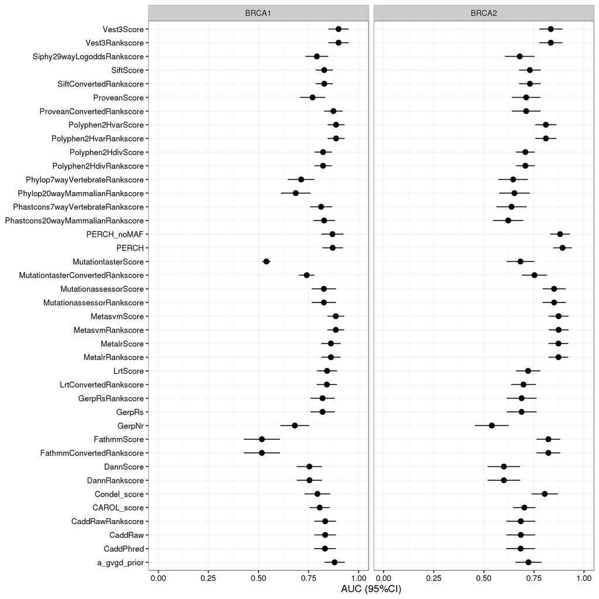

```r
################################################
#  Make forest plot of auc estimates             #
################################################
b2 <- ggplot(brca2a.auc.,aes(x=model,y=auc,ymin=auc.lcl,ymax=auc.ucl))+
  geom_pointrange()+
  ylim(0,1)+
  coord_flip()+
  theme_bw()+
  ylab("AUC (95%CI)")+
  xlab(NULL)+
  ggtitle("BRCA2") +
  scale_colour_grey()

b1 <- ggplot(brca1a.auc.,aes(x=model,y=auc,ymin=auc.lcl,ymax=auc.ucl))+
  geom_pointrange()+
  ylim(0,1)+
  coord_flip()+
  theme_bw()+
  ylab("AUC (95%CI)")+
  ggtitle("BRCA1")+
  theme(axis.text.y = element_blank())+
  xlab(NULL) + scale_colour_grey()


tmp1  <- brca1a.auc.
tmp1$Gene = "BRCA1"
tmp2  <- brca2a.auc.
tmp2$Gene = "BRCA2"
tmp<-rbind(tmp1,tmp2)

ggplot(tmp,aes(x=model,y=auc,ymin=auc.lcl,ymax=auc.ucl))+
  geom_pointrange()+
  ylim(0,1)+
  facet_grid(. ~ Gene)+
  coord_flip()+
  theme_bw()+
  ylab("AUC (95%CI)")+
  xlab(NULL)+ scale_colour_grey()
```

```r
ggsave("figures/FIGURE_2.png",width=9,height=7, units="in",dpi = 600)
```

# Figure S1

### Area under the curve (AUC) for optimized thresholds in 40 damaging missense predictors.

Each dot represents the AUC, and bars are the 95% confidence intervals for Scenario 2.

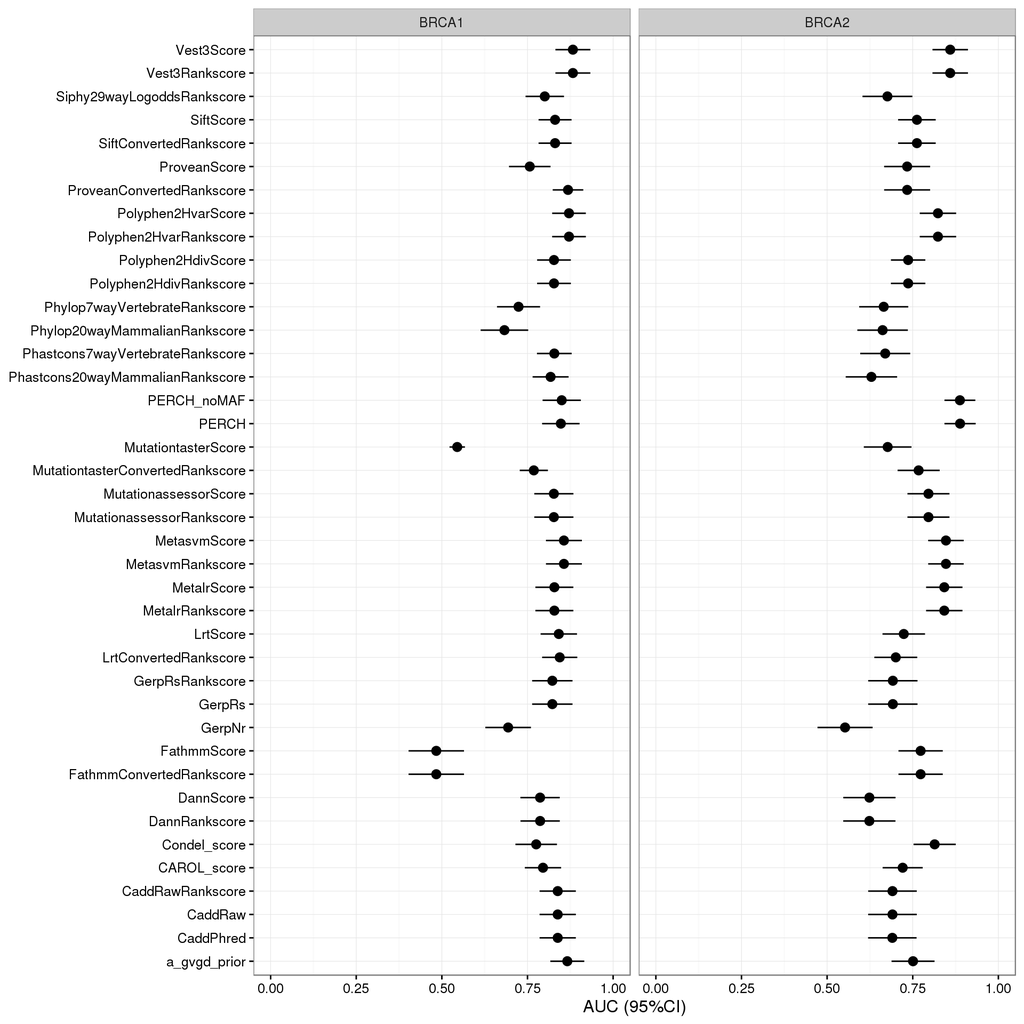

```r
################################################
#  Make forest plot of auc estimates             #
################################################
b2 <- ggplot(brca2b.auc.,aes(x=model,y=auc,ymin=auc.lcl,ymax=auc.ucl))+
  geom_pointrange()+
  ylim(0,1)+
  coord_flip()+
  theme_bw()+
  ylim(0,1)+ylab("AUC (95%CI)")+
  xlab(NULL)+
  ggtitle("BRCA2")

b1 <- ggplot(brca1b.auc.,aes(x=model,y=auc,ymin=auc.lcl,ymax=auc.ucl))+
  geom_pointrange()+
  ylim(0,1)+
  coord_flip()+
  theme_bw()+
  ylab("AUC (95%CI)")+
  ggtitle("BRCA1")+
  theme(axis.text.y = element_blank())+
  xlab(NULL)

tmp1  <- brca1b.auc.
tmp1$Gene = "BRCA1"
tmp2  <- brca2b.auc.
tmp2$Gene = "BRCA2"
tmp<-rbind(tmp1,tmp2)

ggplot(tmp,aes(x=model,y=auc,ymin=auc.lcl,ymax=auc.ucl))+
  geom_pointrange()+
  ylim(0,1)+
  facet_grid(. ~ Gene)+
  coord_flip()+
  theme_bw()+
  ylab("AUC (95%CI)")+
  xlab(NULL)
```

```r
ggsave("figures/FIG_S1.png",width=9,height=7, units="in",dpi = 600)
```

# Code for fitting Random Forests

```r
#############################
# Deleterious vs Int/Neutral#
#############################

##############################
#   BRCA2                            #
##############################

class.del <- factor(vus.brca2$hdr_del)
MODELS<-vus.brca2[,c("CaddRawRankscore","DannRankscore","FathmmConvertedRankscore","GerpNr",
             "GerpRsRankscore","LrtConvertedRankscore","MetalrRankscore","MetasvmRankscore",
              "MutationassessorRankscore","MutationtasterConvertedRankscore",
               "Phastcons20wayMammalianRankscore","Phastcons7wayVertebrateRankscore",
                "Phylop20wayMammalianRankscore",
                  "Phylop7wayVertebrateRankscore","Polyphen2HdivRankscore","Polyphen2HvarRankscore",
                    "ProveanConvertedRankscore",
                    "SiftConvertedRankscore","Siphy29wayLogoddsRankscore","Vest3Rankscore",
                     "a_gvgd_prior","PERCH")]

#set.seed(559)
#tune2a <- tune.randomForest(y=class.del,x=MODELS,mtry=c(2,3,4,5,6,7,8,9,10),ntree=c(500))

#tune2b <- tuneRF(x=MODELS,y=class.del,ntreeTry=500,stepFactor=1.5,plot=T)

set.seed(559)

rf.brca2.del <- randomForest(factor(hdr_del)~
                               CaddRawRankscore+DannRankscore+FathmmConvertedRankscore+
                                   GerpNr+GerpRsRankscore+LrtConvertedRankscore+MetalrRankscore+
                                   MetasvmRankscore+
                               MutationassessorRankscore+MutationtasterConvertedRankscore+
                               Phastcons20wayMammalianRankscore+Phastcons7wayVertebrateRankscore+
                               Phylop20wayMammalianRankscore+
                               Phylop7wayVertebrateRankscore+Polyphen2HdivRankscore+
                               Polyphen2HvarRankscore+
                               ProveanConvertedRankscore+
                               SiftConvertedRankscore+Siphy29wayLogoddsRankscore+Vest3Rankscore+
                               a_gvgd_prior+PERCH,
                               importance=T,proximity=T,ntree=500,mtry=4,
                               keep.forest=T,data=vus.brca2)

imp2del <- as.data.frame(importance(rf.brca2.del,type=1))
imp2del. <- imp2del[order(imp2del$MeanDecreaseAccuracy),,drop=FALSE]

rf.brca2.pred.del <- predict(rf.brca2.del,type='prob')
vus.brca2. <- cbind(vus.brca2,round(rf.brca2.pred.del[,2],digits=3))
colnames(vus.brca2.)[76] <- "rf_prob_del"

#Add RF prediction for BRCA2 variants without functional data
brca2.del.new <- predict(rf.brca2.del,type='prob',newdata=all2)

all2. <- cbind(all2,round(brca2.del.new[,2],digits=3))
colnames(all2.)[74] <- "rf_prob_del"

##############################
#   BRCA1                            #
##############################

class.del <- factor(vus.brca1$hdr_del)
MODELS<-vus.brca1[,c("CAROL_score","Condel_score","CaddRawRankscore","DannRankscore",
                     "FathmmConvertedRankscore","GerpNr",
                     "GerpRsRankscore","LrtConvertedRankscore","MetalrRankscore",
                     "MetasvmRankscore",
                     "MutationassessorRankscore","MutationtasterConvertedRankscore",
                     "Phastcons20wayMammalianRankscore","Phastcons7wayVertebrateRankscore",
                     "Phylop20wayMammalianRankscore",
                     "Phylop7wayVertebrateRankscore","Polyphen2HdivRankscore","Polyphen2HvarRankscore",
                     "ProveanConvertedRankscore",
                     "SiftConvertedRankscore","Siphy29wayLogoddsRankscore","Vest3Rankscore",
                     "a_gvgd_prior","PERCH")]

#set.seed(559)
#tune1a <- tune.randomForest(y=class.del,x=MODELS,mtry=c(2,3,4,5,6,7,8,9,10),
#                                ntree=c(250,500,1000))

#tune1b <- tuneRF(x=MODELS,y=class.del,ntreeTry=500,stepFactor=1.5,plot=T)

set.seed(559)
rf.brca1.del <- randomForest(factor(hdr_del)~CaddRawRankscore+DannRankscore+FathmmConvertedRankscore+
                          GerpNr+GerpRsRankscore+LrtConvertedRankscore+MetalrRankscore+MetasvmRankscore+
                      MutationassessorRankscore+MutationtasterConvertedRankscore+
                      Phastcons20wayMammalianRankscore+Phastcons7wayVertebrateRankscore+
                      Phylop20wayMammalianRankscore+
                      Phylop7wayVertebrateRankscore+Polyphen2HdivRankscore+
                          Polyphen2HvarRankscore+ProveanConvertedRankscore+
                      SiftConvertedRankscore+Siphy29wayLogoddsRankscore+
                      Vest3Rankscore+a_gvgd_prior+PERCH+
                      CAROL_score+Condel_score,
                      importance=T,proximity=T,ntree=500,data=vus.brca1,
                      keep.forest=T,mtry=4)

imp1del <- as.data.frame(importance(rf.brca1.del,type=1))
imp1del. <- imp1del[order(imp1del$MeanDecreaseAccuracy),,drop=FALSE]

rf.brca1.pred.del <- predict(rf.brca1.del,type='prob')
vus.brca1. <- cbind(vus.brca1,round(rf.brca1.pred.del[,2],digits=3))
colnames(vus.brca1.)[76] <- "rf_prob_del"

#Add RF prediction for BRCA1 variants without functional data
brca1.del.new <- predict(rf.brca1.del,type='prob',newdata=all1)

all1. <- cbind(all1,round(brca1.del.new[,2],digits=3))
colnames(all1.)[74] <- "rf_prob_del"

####################################
# Del/Int vs Neutral                   #
####################################

##############################
#   BRCA2                            #
##############################

class.delint <- factor(vus.brca2$hdr_not_neutral)
MODELS<-vus.brca2[,c("CaddRawRankscore","DannRankscore","FathmmConvertedRankscore","GerpNr",
             "GerpRsRankscore","LrtConvertedRankscore","MetalrRankscore","MetasvmRankscore",
              "MutationassessorRankscore","MutationtasterConvertedRankscore",
               "Phastcons20wayMammalianRankscore","Phastcons7wayVertebrateRankscore",
                 "Phylop20wayMammalianRankscore",
                  "Phylop7wayVertebrateRankscore","Polyphen2HdivRankscore","Polyphen2HvarRankscore",
                    "ProveanConvertedRankscore",
                      "SiftConvertedRankscore","Siphy29wayLogoddsRankscore","Vest3Rankscore",
                       "a_gvgd_prior","PERCH")]

#set.seed(420)
#tune2b <- tuneRF(x=MODELS,y=class.delint,ntreeTry=500,stepFactor=1.5,plot=T)

set.seed(420)
#rf.brca2.delint <- randomForest(y=class.delint,x=MODELS,importance=T,proximity=T,ntree=500,
#                 keep.forest=T,mtry=4)


rf.brca2.delint <- randomForest(factor(hdr_not_neutral)~CaddRawRankscore+DannRankscore+
                                  FathmmConvertedRankscore+
                                      GerpNr+GerpRsRankscore+LrtConvertedRankscore+MetalrRankscore+
                                      MetasvmRankscore+
                                  MutationassessorRankscore+MutationtasterConvertedRankscore+
                                  Phastcons20wayMammalianRankscore+Phastcons7wayVertebrateRankscore+
                                  Phylop20wayMammalianRankscore+
                                  Phylop7wayVertebrateRankscore+Polyphen2HdivRankscore+
                                  Polyphen2HvarRankscore+
                                  ProveanConvertedRankscore+
                                  SiftConvertedRankscore+Siphy29wayLogoddsRankscore+Vest3Rankscore+
                                  a_gvgd_prior+PERCH,
                                  importance=T,proximity=T,ntree=500,
                                  keep.forest=T,mtry=4,data=vus.brca2)

imp2delint <- as.data.frame(importance(rf.brca2.delint,type=1))
imp2delint. <- imp2delint[order(imp2delint$MeanDecreaseAccuracy),,drop=FALSE]

rf.brca2.pred.delint <- predict(rf.brca2.delint,type='prob')

vus.brca2.. <- cbind(vus.brca2.,round(rf.brca2.pred.delint[,2],digits=3))
colnames(vus.brca2..)[77] <- "rf_prob_delint"

#Add RF prediction for BRCA2 variants without functional data
brca2.delint.new <- predict(rf.brca2.delint,type='prob',newdata=all2)

all2.. <- cbind(all2.,round(brca2.delint.new[,2],digits=3))
colnames(all2..)[75] <- "rf_prob_delint"


##############################
#   BRCA1                            #
##############################


class.delint <- factor(vus.brca1$hdr_not_neutral)
MODELS<-vus.brca1[,c("CAROL_score","Condel_score","CaddRawRankscore","DannRankscore",
                     "FathmmConvertedRankscore","GerpNr",
                     "GerpRsRankscore","LrtConvertedRankscore","MetalrRankscore",
                     "MetasvmRankscore",
                     "MutationassessorRankscore","MutationtasterConvertedRankscore",
                     "Phastcons20wayMammalianRankscore","Phastcons7wayVertebrateRankscore",
                     "Phylop20wayMammalianRankscore",
                     "Phylop7wayVertebrateRankscore","Polyphen2HdivRankscore","Polyphen2HvarRankscore",
                     "ProveanConvertedRankscore",
                     "SiftConvertedRankscore","Siphy29wayLogoddsRankscore","Vest3Rankscore",
                     "a_gvgd_prior","PERCH")]

#set.seed(420)
#tune1b <- tuneRF(x=MODELS,y=class.delint,ntreeTry=500,stepFactor=1.5,plot=T)

set.seed(420)

rf.brca1.delint <- randomForest(factor(hdr_not_neutral)~
                                  CaddRawRankscore+DannRankscore+
                                  FathmmConvertedRankscore+
                                      GerpNr+GerpRsRankscore+LrtConvertedRankscore+
                                      MetalrRankscore+MetasvmRankscore+
                                  MutationassessorRankscore+MutationtasterConvertedRankscore+
                                  Phastcons20wayMammalianRankscore+Phastcons7wayVertebrateRankscore+
                                  Phylop20wayMammalianRankscore+
                                  Phylop7wayVertebrateRankscore+Polyphen2HdivRankscore+
                                  Polyphen2HvarRankscore+
                                  ProveanConvertedRankscore+
                                  SiftConvertedRankscore+Siphy29wayLogoddsRankscore+Vest3Rankscore+
                                  a_gvgd_prior+PERCH+
                                  CAROL_score+
                                  Condel_score,
                                  importance=T,proximity=T,ntree=500,
                                  keep.forest=T,mtry=4,data=vus.brca1)

imp1delint <- as.data.frame(importance(rf.brca1.delint,type=1))
imp1delint. <- imp1delint[order(imp1delint$MeanDecreaseAccuracy),,drop=FALSE]

rf.brca1.pred.delint <- predict(rf.brca1.delint,type='prob')

vus.brca1.. <- cbind(vus.brca1.,round(rf.brca1.pred.delint[,2],digits=3))
colnames(vus.brca1..)[77] <- "rf_prob_delint"

# Add RF prediction for BRCA1 variants without functional data
brca1.delint.new <- predict(rf.brca1.delint,type='prob',newdata=all1)

all1.. <- cbind(all1.,round(brca1.delint.new[,2],digits=3))
colnames(all1..)[75] <- "rf_prob_delint"
```

Random Forest Variable Importance Plot (Scenario 1) - Not used

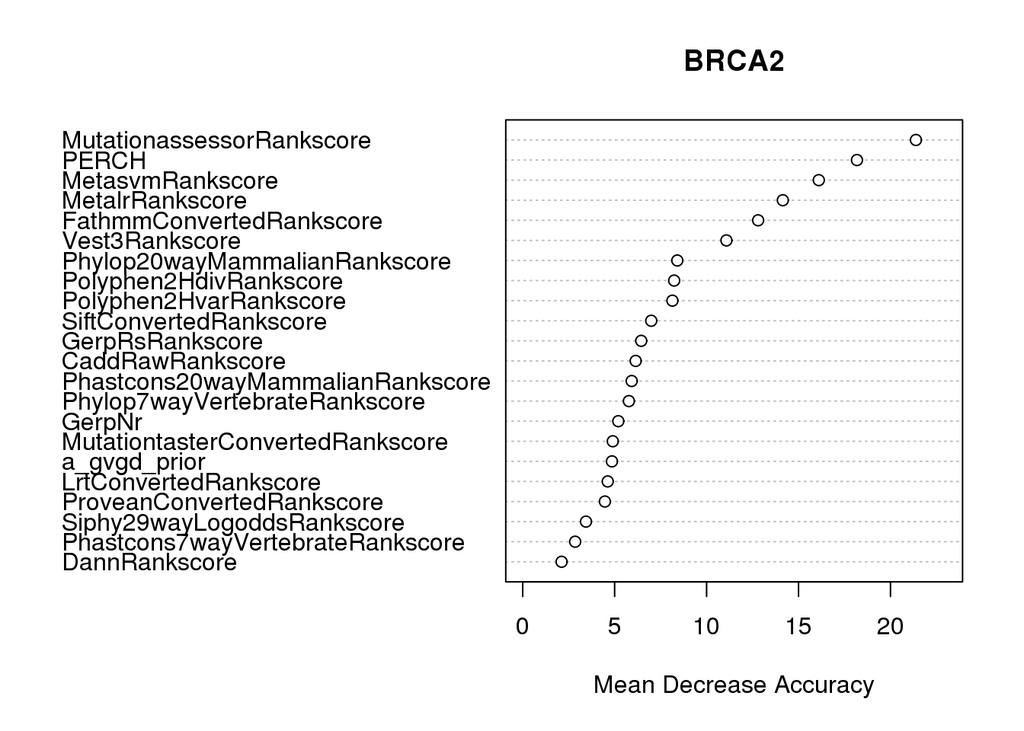

```r
dotchart(imp2del.[,1],labels=rownames(imp2del.),xlim=c(0,23),xlab='Mean Decrease Accuracy',main='BRCA2')
```

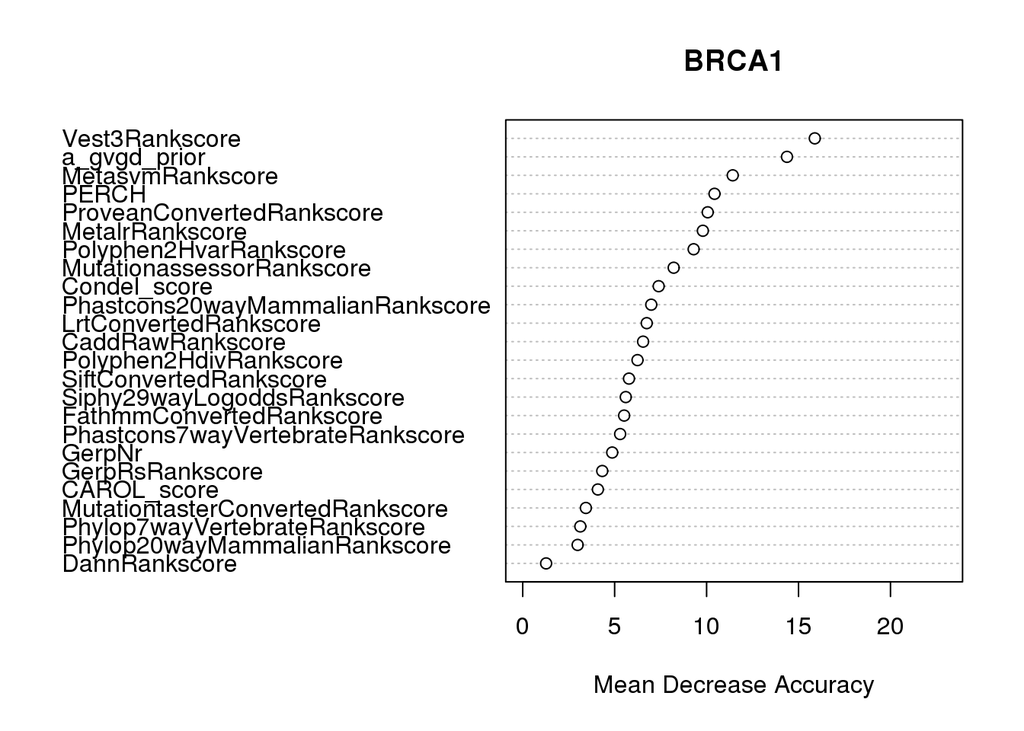

```r
dotchart(imp1del.[,1],labels=rownames(imp1del.),xlim=c(0,23),xlab='Mean Decrease Accuracy',main='BRCA1')
```

```r
par(xpd=T)
```

Random Forest Variable Importance Plot (Scenario 2)

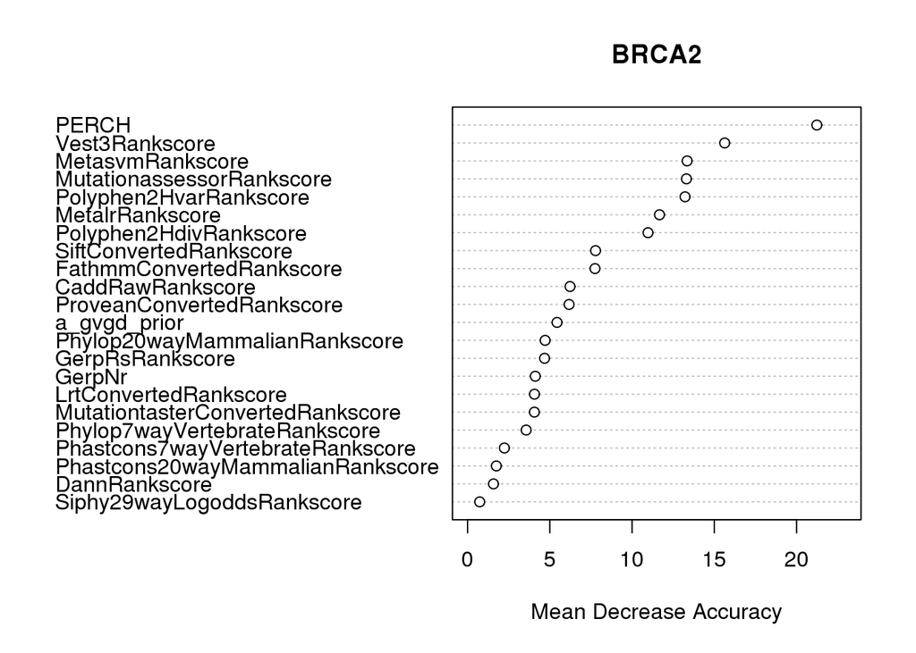

```r
dotchart(imp2delint.[,1],labels=rownames(imp2delint.),xlim=c(0,23),xlab='Mean Decrease Accuracy',main='BRCA2')
```

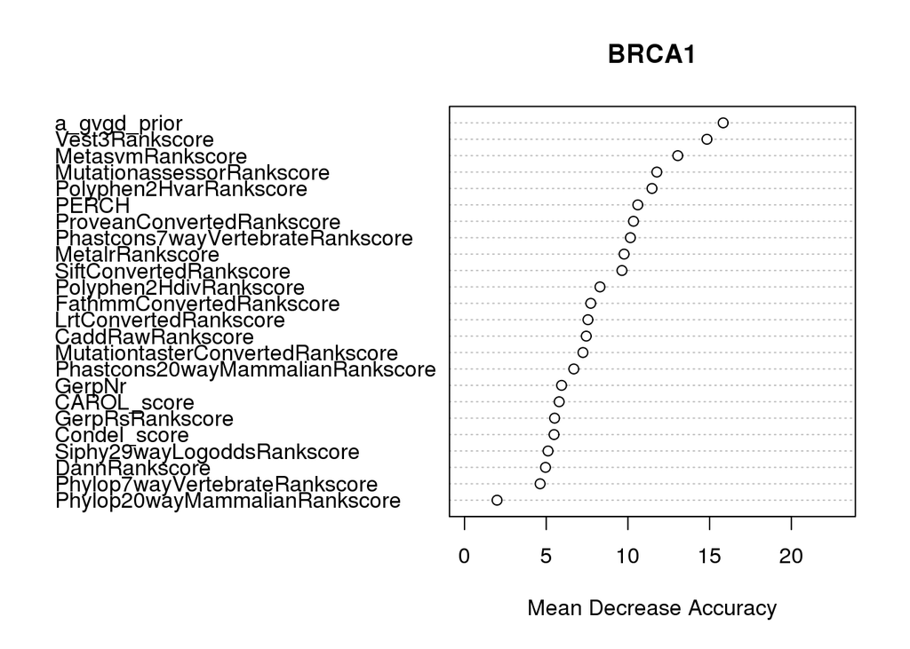

```r
dotchart(imp1delint.[,1],labels=rownames(imp1delint.),xlim=c(0,23),xlab='Mean Decrease Accuracy',main='BRCA1')
```

```r
par(xpd=T)
```

# Code for fitting NVM

```r
brca2$perch_del <- ifelse(brca2$PERCH>=0.295957,1,0)
brca2$metasvmrank_del <- ifelse(brca2$MetasvmRankscore>=0.93181,1,0)
brca2$metalrrank_del <- ifelse(brca2$MetalrRankscore>=0.92107,1,0)
brca2$mutationassessor_del <- ifelse(brca2$MutationassessorRankscore>=0.84368,1,0)
brca2$vest3rank_del <- ifelse(brca2$Vest3Rankscore>=0.79963,1,0)
brca2$pp2hvarrank_del <- ifelse(brca2$Polyphen2HvarRankscore>=0.97092,1,0)
brca2$fathmm_del <- ifelse(brca2$FathmmConvertedRankscore>=0.8581,1,0)
brca2$mutationtaster_del <- ifelse(brca2$MutationtasterConvertedRankscore>=0.58814,1,0)
brca2$sift_del <- ifelse(brca2$SiftConvertedRankscore>=0.9122,1,0)
brca2$agvgd_del <- ifelse(brca2$a_gvgd_prior>=0.81,1,0)
brca2$lrt_del <- ifelse(brca2$LrtScore<=0,1,0)
brca2$provean_del <- ifelse(brca2$ProveanConvertedRankscore>=0.42352,1,0)
brca2$pp2hdiv_del <- ifelse(brca2$Polyphen2HdivRankscore>=0.89865,1,0)
brca2$gerprs_del <- ifelse(brca2$GerpRsRankscore>=0.7396,1,0)
brca2$cadd_del <- ifelse(brca2$CaddPhred>=29.4,1,0)
brca2$siphy_del <- ifelse(brca2$Siphy29wayLogoddsRankscore>=0.78299,1,0)
brca2$phylopmammal_del <- ifelse(brca2$Phylop20wayMammalianRankscore>=0.63346,1,0)
brca2$phylopvertebrate_del <- ifelse(brca2$Phylop7wayVertebrateRankscore>=0.76621,1,0)
brca2$phastconsvertebrate_del <- ifelse(brca2$Phastcons7wayVertebrateRankscore>=0.61045,1,0)
brca2$phastconsmammal_del <- ifelse(brca2$Phastcons20wayMammalianRankscore>=0.60234,1,0)
brca2$dann_del <- ifelse(brca2$DannRankscore>=0.84566,1,0)
brca2$gerpnr_del <- ifelse(brca2$GerpNr>=5.49,1,0)

brca2$sum_del_1 = with(brca2, perch_del)
brca2$sum_del_2 = with(brca2, perch_del+metasvmrank_del)
brca2$sum_del_3 = with(brca2, perch_del+metasvmrank_del+metalrrank_del)
brca2$sum_del_4 = with(brca2, perch_del+metasvmrank_del+metalrrank_del+vest3rank_del)
brca2$sum_del_5 = with(brca2, perch_del+metasvmrank_del+metalrrank_del+vest3rank_del+
                          pp2hvarrank_del)
brca2$sum_del_6 = with(brca2, perch_del+metasvmrank_del+metalrrank_del+vest3rank_del+pp2hvarrank_del+
                   mutationassessor_del)
brca2$sum_del_7 = with(brca2, perch_del+metasvmrank_del+metalrrank_del+vest3rank_del+pp2hvarrank_del+
                   mutationassessor_del+pp2hdiv_del)
brca2$sum_del_8 = with(brca2, perch_del+metasvmrank_del+metalrrank_del+vest3rank_del+pp2hvarrank_del+
                   mutationassessor_del+pp2hdiv_del+fathmm_del)
brca2$sum_del_9 = with(brca2, perch_del+metasvmrank_del+metalrrank_del+vest3rank_del+pp2hvarrank_del+
                   mutationassessor_del+pp2hdiv_del+fathmm_del+sift_del)
brca2$sum_del_10 = with(brca2, perch_del+metasvmrank_del+metalrrank_del+vest3rank_del+pp2hvarrank_del+
                   mutationassessor_del+pp2hdiv_del+fathmm_del+sift_del+mutationtaster_del)
brca2$sum_del_11 = with(brca2, perch_del+metasvmrank_del+metalrrank_del+vest3rank_del+pp2hvarrank_del+
                   mutationassessor_del+pp2hdiv_del+fathmm_del+sift_del+mutationtaster_del+
                     lrt_del)
brca2$sum_del_12 = with(brca2, perch_del+metasvmrank_del+metalrrank_del+vest3rank_del+pp2hvarrank_del+
                   mutationassessor_del+pp2hdiv_del+fathmm_del+sift_del+mutationtaster_del+
                     lrt_del+agvgd_del)
brca2$sum_del_13 = with(brca2, perch_del+metasvmrank_del+metalrrank_del+vest3rank_del+pp2hvarrank_del+
                   mutationassessor_del+pp2hdiv_del+fathmm_del+sift_del+mutationtaster_del+
                     lrt_del+agvgd_del+provean_del)
brca2$sum_del_14 = with(brca2, perch_del+metasvmrank_del+metalrrank_del+vest3rank_del+pp2hvarrank_del+
                   mutationassessor_del+pp2hdiv_del+fathmm_del+sift_del+mutationtaster_del+
                     lrt_del+agvgd_del+provean_del+cadd_del)
brca2$sum_del_15 = with(brca2, perch_del+metasvmrank_del+metalrrank_del+vest3rank_del+pp2hvarrank_del+
                   mutationassessor_del+pp2hdiv_del+fathmm_del+sift_del+mutationtaster_del+
                     lrt_del+agvgd_del+provean_del+cadd_del+gerprs_del)
brca2$sum_del_16 = with(brca2, perch_del+metasvmrank_del+metalrrank_del+vest3rank_del+pp2hvarrank_del+
                   mutationassessor_del+pp2hdiv_del+fathmm_del+sift_del+mutationtaster_del+
                     lrt_del+agvgd_del+provean_del+cadd_del+gerprs_del+siphy_del)
brca2$sum_del_17 = with(brca2, perch_del+metasvmrank_del+metalrrank_del+vest3rank_del+pp2hvarrank_del+
                   mutationassessor_del+pp2hdiv_del+fathmm_del+sift_del+mutationtaster_del+
                     lrt_del+agvgd_del+provean_del+cadd_del+gerprs_del+siphy_del+phastconsvertebrate_del)
brca2$sum_del_18 = with(brca2, perch_del+metasvmrank_del+metalrrank_del+vest3rank_del+pp2hvarrank_del+
                   mutationassessor_del+pp2hdiv_del+fathmm_del+sift_del+mutationtaster_del+
                     lrt_del+agvgd_del+provean_del+cadd_del+gerprs_del+siphy_del+phastconsvertebrate_del+
                      phylopmammal_del)
brca2$sum_del_19 = with(brca2, perch_del+metasvmrank_del+metalrrank_del+vest3rank_del+pp2hvarrank_del+
                   mutationassessor_del+pp2hdiv_del+fathmm_del+sift_del+mutationtaster_del+
                     lrt_del+agvgd_del+provean_del+cadd_del+gerprs_del+siphy_del+phastconsvertebrate_del+
                      phylopmammal_del+phylopvertebrate_del)
brca2$sum_del_20 = with(brca2, perch_del+metasvmrank_del+metalrrank_del+vest3rank_del+pp2hvarrank_del+
                   mutationassessor_del+pp2hdiv_del+fathmm_del+sift_del+mutationtaster_del+
                     lrt_del+agvgd_del+provean_del+cadd_del+gerprs_del+siphy_del+phastconsvertebrate_del+
                      phylopmammal_del+phylopvertebrate_del+gerpnr_del)
brca2$sum_del_21 = with(brca2, perch_del+metasvmrank_del+metalrrank_del+vest3rank_del+pp2hvarrank_del+
                   mutationassessor_del+pp2hdiv_del+fathmm_del+sift_del+mutationtaster_del+
                     lrt_del+agvgd_del+provean_del+cadd_del+gerprs_del+siphy_del+phastconsvertebrate_del+
                      phylopmammal_del+phylopvertebrate_del+gerpnr_del+phastconsmammal_del)
brca2$sum_del_22 = with(brca2, perch_del+metasvmrank_del+metalrrank_del+vest3rank_del+pp2hvarrank_del+
                   mutationassessor_del+pp2hdiv_del+fathmm_del+sift_del+mutationtaster_del+
                     lrt_del+agvgd_del+provean_del+cadd_del+gerprs_del+siphy_del+phastconsvertebrate_del+
                      phylopmammal_del+phylopvertebrate_del+gerpnr_del+phastconsmammal_del+
                        dann_del)
```

```r
brca2$perch_nn <- ifelse(brca2$PERCH>=0.232796,1,0)
brca2$metasvmrank_nn <- ifelse(brca2$MetasvmRankscore>=0.92233,1,0)
brca2$metalrrank_nn <- ifelse(brca2$MetalrRankscore>=0.91514,1,0)
brca2$mutationassessor_nn <- ifelse(brca2$MutationassessorRankscore>=0.83541,1,0)
brca2$vest3rank_nn <- ifelse(brca2$Vest3Rankscore>=0.7831,1,0)
brca2$fathmm_nn <- ifelse(brca2$FathmmConvertedRankscore>=0.84569,1,0)
brca2$pp2hvarrank_nn <- ifelse(brca2$Polyphen2HvarRankscore>=0.97092,1,0)
brca2$mutationtaster_nn <- ifelse(brca2$MutationtasterConvertedRankscore>=0.58814,1,0)
brca2$sift_nn <- ifelse(brca2$SiftConvertedRankscore>=0.91219,1,0)
brca2$agvgd_nn <- ifelse(brca2$a_gvgd_prior>=0.81,1,0)
brca2$lrt_nn <- ifelse(brca2$LrtScore<=0,1,0)
brca2$provean_nn <- ifelse(brca2$ProveanConvertedRankscore>=0.4197,1,0)
brca2$pp2hdiv_nn <- ifelse(brca2$Polyphen2HdivRankscore>=0.89865,1,0)
brca2$gerprs_nn <- ifelse(brca2$GerpRsRankscore>=0.71253,1,0)
brca2$cadd_nn <- ifelse(brca2$CaddRawRankscore>=0.86323,1,0)
brca2$siphy_nn <- ifelse(brca2$Siphy29wayLogoddsRankscore>=0.75958,1,0)
brca2$phylopmammal_nn <- ifelse(brca2$Phylop20wayMammalianRankscore>=0.61215,1,0)
brca2$phylopvertebrate_nn <- ifelse(brca2$Phylop7wayVertebrateRankscore>=0.76621,1,0)
brca2$phastconsvertebrate_nn <- ifelse(brca2$Phastcons7wayVertebrateRankscore>=0.59096,1,0)
brca2$phastconsmammal_nn <- ifelse(brca2$Phastcons20wayMammalianRankscore>=0.60234,1,0)
brca2$dann_nn <- ifelse(brca2$DannRankscore>=0.8433,1,0)
brca2$gerpnr_nn <- ifelse(brca2$GerpNr>=5.49,1,0)

brca2$sum_nn_1 = with(brca2, perch_nn)
brca2$sum_nn_2 = with(brca2, perch_nn+vest3rank_nn)
brca2$sum_nn_3 = with(brca2, perch_nn+vest3rank_nn+metalrrank_nn)
brca2$sum_nn_4 = with(brca2, perch_nn+vest3rank_nn+metalrrank_nn+pp2hvarrank_nn)
brca2$sum_nn_5 = with(brca2, perch_nn+vest3rank_nn+metalrrank_nn+pp2hvarrank_nn+metasvmrank_nn)
brca2$sum_nn_6 = with(brca2, perch_nn+vest3rank_nn+metasvmrank_nn+metalrrank_nn+pp2hvarrank_nn+
                 pp2hdiv_nn)
brca2$sum_nn_7 = with(brca2, perch_nn+vest3rank_nn+metasvmrank_nn+metalrrank_nn+pp2hvarrank_nn+
                 pp2hdiv_nn+sift_nn)
brca2$sum_nn_8 = with(brca2, perch_nn+vest3rank_nn+metasvmrank_nn+metalrrank_nn+pp2hvarrank_nn+
                 pp2hdiv_nn+sift_nn+mutationassessor_nn)
brca2$sum_nn_9 = with(brca2, perch_nn+vest3rank_nn+metasvmrank_nn+metalrrank_nn+pp2hvarrank_nn+
                 pp2hdiv_nn+sift_nn+mutationassessor_nn+mutationtaster_nn)
brca2$sum_nn_10 = with(brca2, perch_nn+vest3rank_nn+metasvmrank_nn+metalrrank_nn+pp2hvarrank_nn+
                 pp2hdiv_nn+sift_nn+mutationassessor_nn+mutationtaster_nn+lrt_nn)
brca2$sum_nn_11 = with(brca2,perch_nn+vest3rank_nn+metasvmrank_nn+metalrrank_nn+pp2hvarrank_nn+
                 pp2hdiv_nn+sift_nn+mutationassessor_nn+mutationtaster_nn+lrt_nn+
                 agvgd_nn)
brca2$sum_nn_12 = with(brca2,perch_nn+vest3rank_nn+metasvmrank_nn+metalrrank_nn+pp2hvarrank_nn+
                 pp2hdiv_nn+sift_nn+mutationassessor_nn+mutationtaster_nn+lrt_nn+
                 agvgd_nn+fathmm_nn)
brca2$sum_nn_13 = with(brca2,perch_nn+vest3rank_nn+metasvmrank_nn+metalrrank_nn+pp2hvarrank_nn+
                 pp2hdiv_nn+sift_nn+mutationassessor_nn+mutationtaster_nn+lrt_nn+
                 agvgd_nn+fathmm_nn+provean_nn)
brca2$sum_nn_14 = with(brca2,perch_nn+vest3rank_nn+metasvmrank_nn+metalrrank_nn+pp2hvarrank_nn+
                 pp2hdiv_nn+sift_nn+mutationassessor_nn+mutationtaster_nn+lrt_nn+
                 agvgd_nn+fathmm_nn+provean_nn+phastconsvertebrate_nn)
brca2$sum_nn_15 = with(brca2,perch_nn+vest3rank_nn+metasvmrank_nn+metalrrank_nn+pp2hvarrank_nn+
                 pp2hdiv_nn+sift_nn+mutationassessor_nn+mutationtaster_nn+lrt_nn+
                 agvgd_nn+fathmm_nn+provean_nn+phastconsvertebrate_nn+cadd_nn)
brca2$sum_nn_16 = with(brca2, perch_nn+vest3rank_nn+metasvmrank_nn+metalrrank_nn+pp2hvarrank_nn+
                 pp2hdiv_nn+sift_nn+mutationassessor_nn+mutationtaster_nn+lrt_nn+
                 agvgd_nn+fathmm_nn+provean_nn+phastconsvertebrate_nn+cadd_nn+
                 siphy_nn)
brca2$sum_nn_17 = with(brca2, perch_nn+vest3rank_nn+metasvmrank_nn+metalrrank_nn+pp2hvarrank_nn+
                 pp2hdiv_nn+sift_nn+mutationassessor_nn+mutationtaster_nn+lrt_nn+
                 agvgd_nn+fathmm_nn+provean_nn+phastconsvertebrate_nn+cadd_nn+
                 siphy_nn+gerprs_nn)
brca2$sum_nn_18 = with(brca2, perch_nn+vest3rank_nn+metasvmrank_nn+metalrrank_nn+pp2hvarrank_nn+
                 pp2hdiv_nn+sift_nn+mutationassessor_nn+mutationtaster_nn+lrt_nn+
                 agvgd_nn+fathmm_nn+provean_nn+phastconsvertebrate_nn+cadd_nn+
                 siphy_nn+gerprs_nn+phylopmammal_nn)
brca2$sum_nn_19 = with(brca2, perch_nn+vest3rank_nn+metasvmrank_nn+metalrrank_nn+pp2hvarrank_nn+
                 pp2hdiv_nn+sift_nn+mutationassessor_nn+mutationtaster_nn+lrt_nn+
                 agvgd_nn+fathmm_nn+provean_nn+phastconsvertebrate_nn+cadd_nn+
                 siphy_nn+gerprs_nn+phylopmammal_nn+phylopvertebrate_nn)
brca2$sum_nn_20 = with(brca2, perch_nn+vest3rank_nn+metasvmrank_nn+metalrrank_nn+pp2hvarrank_nn+
                 pp2hdiv_nn+sift_nn+mutationassessor_nn+mutationtaster_nn+lrt_nn+
                 agvgd_nn+fathmm_nn+provean_nn+phastconsvertebrate_nn+cadd_nn+
                 siphy_nn+gerprs_nn+phylopmammal_nn+phylopvertebrate_nn+gerpnr_nn)
brca2$sum_nn_21 = with(brca2, perch_nn+vest3rank_nn+metasvmrank_nn+metalrrank_nn+pp2hvarrank_nn+
                 pp2hdiv_nn+sift_nn+mutationassessor_nn+mutationtaster_nn+lrt_nn+
                 agvgd_nn+fathmm_nn+provean_nn+phastconsvertebrate_nn+cadd_nn+
                 siphy_nn+gerprs_nn+phylopmammal_nn+phylopvertebrate_nn+gerpnr_nn+
                 dann_nn)
brca2$sum_nn_22 = with(brca2, perch_nn+vest3rank_nn+metasvmrank_nn+metalrrank_nn+pp2hvarrank_nn+
                 pp2hdiv_nn+sift_nn+mutationassessor_nn+mutationtaster_nn+lrt_nn+
                 agvgd_nn+fathmm_nn+provean_nn+phastconsvertebrate_nn+cadd_nn+
                 siphy_nn+gerprs_nn+phylopmammal_nn+phylopvertebrate_nn+gerpnr_nn+
                 dann_nn+ phastconsmammal_nn)
```

```r
#BRCA1


brca1$perch_del <- ifelse(brca1$PERCH_noMAF>=0.206316,1,0)
brca1$metasvmrank_del <- ifelse(brca1$MetasvmRankscore>=0.9083,1,0)
brca1$metalrrank_del <- ifelse(brca1$MetalrRankscore>=0.90291,1,0)
brca1$mutationassessor_del <- ifelse(brca1$MutationassessorRankscore>=0.54432,1,0)
brca1$vest3rank_del <- ifelse(brca1$Vest3Rankscore>=0.85546,1,0)
brca1$fathmm_del <- ifelse(brca1$FathmmConvertedRankscore>=0.88158,1,0)
brca1$pp2hvarrank_del <- ifelse(brca1$Polyphen2HvarRankscore>=0.91584,1,0)
brca1$mutationtaster_del <- ifelse(brca1$MutationtasterConvertedRankscore>=0.81033,1,0)
brca1$sift_del <- ifelse(brca1$SiftConvertedRankscore>=0.91219,1,0)
brca1$agvgd_del <- ifelse(brca1$a_gvgd_prior>=0.29,1,0)
brca1$lrt_del <- ifelse(brca1$LrtScore<=0.000926,1,0)
brca1$provean_del <- ifelse(brca1$ProveanConvertedRankscore>=0.69906,1,0)
brca1$pp2hdiv_del <- ifelse(brca1$Polyphen2HdivRankscore>=0.89865,1,0)
brca1$gerprs_del <- ifelse(brca1$GerpRsRankscore>=0.67646,1,0)
brca1$cadd_del <- ifelse(brca1$CaddRawRankscore>=0.66888,1,0)
brca1$siphy_del <- ifelse(brca1$Siphy29wayLogoddsRankscore>=0.49967,1,0)
brca1$phylopmammal_del <- ifelse(brca1$Phylop20wayMammalianRankscore>=0.48891,1,0)
brca1$phylopvertebrate_del <- ifelse(brca1$Phylop7wayVertebrateRankscore>=0.60462,1,0)
brca1$phastconsvertebrate_del <- ifelse(brca1$Phastcons7wayVertebrateRankscore>=0.54028,1,0)
brca1$phastconsmammal_del <- ifelse(brca1$Phastcons20wayMammalianRankscore>=0.51549,1,0)
brca1$dann_del <- ifelse(brca1$DannRankscore>=0.69278,1,0)
brca1$gerpnr_del <- ifelse(brca1$GerpNr>=5.22,1,0)
brca1$carol_del <- ifelse(brca1$CAROL_score>=1,1,0)
brca1$condel_del <- ifelse(brca1$Condel_score>=0.689,1,0)

brca1$sum_del_1 = with(brca1, vest3rank_del)
brca1$sum_del_2 = with(brca1, vest3rank_del+perch_del)
brca1$sum_del_3 = with(brca1, vest3rank_del+perch_del+agvgd_del)
brca1$sum_del_4 = with(brca1, vest3rank_del+perch_del+agvgd_del+pp2hvarrank_del)
brca1$sum_del_5 = with(brca1, vest3rank_del+perch_del+agvgd_del+pp2hvarrank_del+metasvmrank_del)
brca1$sum_del_6 = with(brca1, vest3rank_del+perch_del+agvgd_del+pp2hvarrank_del+metasvmrank_del+
                  sift_del)
brca1$sum_del_7 = with(brca1, vest3rank_del+perch_del+agvgd_del+pp2hvarrank_del+metasvmrank_del+
                  sift_del+pp2hdiv_del)
brca1$sum_del_8 = with(brca1, vest3rank_del+perch_del+agvgd_del+pp2hvarrank_del+metasvmrank_del+
                  sift_del+pp2hdiv_del+gerprs_del)
brca1$sum_del_9 = with(brca1, vest3rank_del+perch_del+agvgd_del+pp2hvarrank_del+metasvmrank_del+
                  sift_del+pp2hdiv_del+gerprs_del+lrt_del)
brca1$sum_del_10 = with(brca1, vest3rank_del+perch_del+agvgd_del+pp2hvarrank_del+metasvmrank_del+
                  sift_del+pp2hdiv_del+gerprs_del+lrt_del+provean_del)
brca1$sum_del_11 = with(brca1, vest3rank_del+perch_del+agvgd_del+pp2hvarrank_del+metasvmrank_del+
                  sift_del+pp2hdiv_del+gerprs_del+lrt_del+provean_del+mutationassessor_del)
brca1$sum_del_12 = with(brca1, vest3rank_del+perch_del+agvgd_del+pp2hvarrank_del+metasvmrank_del+
                  sift_del+pp2hdiv_del+gerprs_del+lrt_del+provean_del+mutationassessor_del+
                   metalrrank_del)
brca1$sum_del_13 = with(brca1, vest3rank_del+perch_del+agvgd_del+pp2hvarrank_del+metasvmrank_del+
                  sift_del+pp2hdiv_del+gerprs_del+lrt_del+provean_del+mutationassessor_del+
                   metalrrank_del+phastconsvertebrate_del)
brca1$sum_del_14 = with(brca1, vest3rank_del+perch_del+agvgd_del+pp2hvarrank_del+metasvmrank_del+
                   sift_del+pp2hdiv_del+gerprs_del+lrt_del+provean_del+mutationassessor_del+
                   metalrrank_del+phastconsvertebrate_del+mutationtaster_del)
brca1$sum_del_15 = with(brca1, vest3rank_del+perch_del+agvgd_del+pp2hvarrank_del+metasvmrank_del+
                   sift_del+pp2hdiv_del+gerprs_del+lrt_del+provean_del+mutationassessor_del+
                   metalrrank_del+phastconsvertebrate_del+mutationtaster_del+carol_del)
brca1$sum_del_16 = with(brca1, vest3rank_del+perch_del+agvgd_del+pp2hvarrank_del+metasvmrank_del+
                   sift_del+pp2hdiv_del+gerprs_del+lrt_del+provean_del+mutationassessor_del+
                   metalrrank_del+phastconsvertebrate_del+mutationtaster_del+carol_del+siphy_del)
brca1$sum_del_17 = with(brca1, vest3rank_del+perch_del+agvgd_del+pp2hvarrank_del+metasvmrank_del+
                   sift_del+pp2hdiv_del+gerprs_del+lrt_del+provean_del+mutationassessor_del+
                   metalrrank_del+phastconsvertebrate_del+mutationtaster_del+carol_del+siphy_del+
                   cadd_del)
brca1$sum_del_18 = with(brca1, vest3rank_del+perch_del+agvgd_del+pp2hvarrank_del+metasvmrank_del+
                   sift_del+pp2hdiv_del+gerprs_del+lrt_del+provean_del+mutationassessor_del+
                   metalrrank_del+phastconsvertebrate_del+mutationtaster_del+carol_del+siphy_del+cadd_del+
                   phastconsmammal_del)
brca1$sum_del_19 = with(brca1, vest3rank_del+perch_del+agvgd_del+pp2hvarrank_del+metasvmrank_del+
                   sift_del+pp2hdiv_del+gerprs_del+lrt_del+provean_del+mutationassessor_del+
                   metalrrank_del+phastconsvertebrate_del+mutationtaster_del+carol_del+siphy_del+cadd_del+
                   phastconsmammal_del+dann_del)
brca1$sum_del_20 = with(brca1, vest3rank_del+perch_del+agvgd_del+pp2hvarrank_del+metasvmrank_del+
                   sift_del+pp2hdiv_del+gerprs_del+lrt_del+provean_del+mutationassessor_del+
                   metalrrank_del+phastconsvertebrate_del+mutationtaster_del+carol_del+siphy_del+cadd_del+
                   phastconsmammal_del+dann_del+condel_del)
brca1$sum_del_21 = with(brca1, vest3rank_del+perch_del+agvgd_del+pp2hvarrank_del+metasvmrank_del+
                   sift_del+pp2hdiv_del+gerprs_del+lrt_del+provean_del+mutationassessor_del+
                   metalrrank_del+phastconsvertebrate_del+mutationtaster_del+carol_del+siphy_del+cadd_del+
                   phastconsmammal_del+dann_del+condel_del+phylopvertebrate_del)
brca1$sum_del_22 = with(brca1, vest3rank_del+perch_del+agvgd_del+pp2hvarrank_del+metasvmrank_del+
                   sift_del+pp2hdiv_del+gerprs_del+lrt_del+provean_del+mutationassessor_del+
                   metalrrank_del+phastconsvertebrate_del+mutationtaster_del+carol_del+siphy_del+cadd_del+
                   phastconsmammal_del+dann_del+condel_del+phylopvertebrate_del+gerpnr_del)
brca1$sum_del_23 = with(brca1, vest3rank_del+perch_del+agvgd_del+pp2hvarrank_del+metasvmrank_del+
                   sift_del+pp2hdiv_del+gerprs_del+lrt_del+provean_del+mutationassessor_del+
                   metalrrank_del+phastconsvertebrate_del+mutationtaster_del+carol_del+siphy_del+cadd_del+
                   phastconsmammal_del+dann_del+condel_del+phylopvertebrate_del+gerpnr_del+
                   phylopmammal_del)
brca1$sum_del_24 = with(brca1, vest3rank_del+perch_del+agvgd_del+pp2hvarrank_del+metasvmrank_del+
                   sift_del+pp2hdiv_del+gerprs_del+lrt_del+provean_del+mutationassessor_del+
                   metalrrank_del+phastconsvertebrate_del+mutationtaster_del+carol_del+siphy_del+cadd_del+
                   phastconsmammal_del+dann_del+condel_del+phylopvertebrate_del+gerpnr_del+
                   phylopmammal_del+fathmm_del)
```

```r
brca1$perch_nn <- ifelse(brca1$PERCH_noMAF>=0.140337,1,0)
brca1$metasvmrank_nn <- ifelse(brca1$MetasvmRankscore>=0.8874,1,0)
brca1$metalrrank_nn <- ifelse(brca1$MetalrRankscore>=0.89743,1,0)
brca1$mutationassessor_nn <- ifelse(brca1$MutationassessorRankscore>=0.44691,1,0)
brca1$vest3rank_nn <- ifelse(brca1$Vest3Rankscore>=0.80056,1,0)
brca1$fathmm_nn <- ifelse(brca1$FathmmConvertedRankscore>=0.88313,1,0)
brca1$pp2hvarrank_nn <- ifelse(brca1$Polyphen2HvarRankscore>=0.85043,1,0)
brca1$mutationtaster_nn <- ifelse(brca1$MutationtasterConvertedRankscore>=0.81033,1,0)
brca1$sift_nn <- ifelse(brca1$SiftConvertedRankscore>=0.91219,1,0)
brca1$agvgd_nn <- ifelse(brca1$a_gvgd_prior>=0.29,1,0)
brca1$lrt_nn <- ifelse(brca1$LrtConvertedRankscore>=0.38483,1,0)
brca1$provean_nn <- ifelse(brca1$ProveanConvertedRankscore>=0.65469,1,0)
brca1$pp2hdiv_nn <- ifelse(brca1$Polyphen2HdivRankscore>=0.89865,1,0)
brca1$gerprs_nn <- ifelse(brca1$GerpRsRankscore>=0.61659,1,0)
brca1$cadd_nn <- ifelse(brca1$CaddRawRankscore>=0.64548,1,0)
brca1$siphy_nn <- ifelse(brca1$Siphy29wayLogoddsRankscore>=0.48478,1,0)
brca1$phylopmammal_nn <- ifelse(brca1$Phylop20wayMammalianRankscore>=0.48811,1,0)
brca1$phylopvertebrate_nn <- ifelse(brca1$Phylop7wayVertebrateRankscore>=0.60462,1,0)
brca1$phastconsvertebrate_nn <- ifelse(brca1$Phastcons7wayVertebrateRankscore>=0.46971,1,0)
brca1$phastconsmammal_nn <- ifelse(brca1$Phastcons20wayMammalianRankscore>=0.47504,1,0)
brca1$dann_nn <- ifelse(brca1$DannRankscore>=0.67191,1,0)
brca1$gerpnr_nn <- ifelse(brca1$GerpNr>=5.21,1,0)
brca1$carol_nn <- ifelse(brca1$CAROL_score>=1,1,0)
brca1$condel_nn <- ifelse(brca1$Condel_score>=0.674,1,0)

brca1$sum_nn_1 = with(brca1, vest3rank_nn)
brca1$sum_nn_2 = with(brca1, vest3rank_nn+agvgd_nn)
brca1$sum_nn_3 = with(brca1, vest3rank_nn+agvgd_nn+perch_nn)
brca1$sum_nn_4 = with(brca1, vest3rank_nn+agvgd_nn+perch_nn+sift_nn)
brca1$sum_nn_5 = with(brca1, vest3rank_nn+agvgd_nn+perch_nn+sift_nn+metasvmrank_nn)
brca1$sum_nn_6 = with(brca1, vest3rank_nn+agvgd_nn+perch_nn+sift_nn+metasvmrank_nn+pp2hdiv_nn)
brca1$sum_nn_7 = with(brca1, vest3rank_nn+agvgd_nn+perch_nn+sift_nn+metasvmrank_nn+pp2hdiv_nn+
                 pp2hvarrank_nn)
brca1$sum_nn_8 = with(brca1, vest3rank_nn+agvgd_nn+perch_nn+sift_nn+metasvmrank_nn+pp2hdiv_nn+
                 pp2hvarrank_nn+gerprs_nn)
brca1$sum_nn_9 = with(brca1, vest3rank_nn+agvgd_nn+perch_nn+sift_nn+metasvmrank_nn+pp2hdiv_nn+
                 pp2hvarrank_nn+gerprs_nn+lrt_nn)
brca1$sum_nn_10 = with(brca1, vest3rank_nn+agvgd_nn+perch_nn+sift_nn+metasvmrank_nn+pp2hdiv_nn+
                  pp2hvarrank_nn+gerprs_nn+lrt_nn+mutationtaster_nn)
brca1$sum_nn_11 = with(brca1, vest3rank_nn+agvgd_nn+perch_nn+sift_nn+metasvmrank_nn+pp2hdiv_nn+
                  pp2hvarrank_nn+gerprs_nn+lrt_nn+mutationtaster_nn+provean_nn)
brca1$sum_nn_12= with(brca1, vest3rank_nn+agvgd_nn+perch_nn+sift_nn+metasvmrank_nn+pp2hdiv_nn+
                 pp2hvarrank_nn+gerprs_nn+lrt_nn+mutationtaster_nn+provean_nn+
                 cadd_nn)
brca1$sum_nn_13= with(brca1, vest3rank_nn+agvgd_nn+perch_nn+sift_nn+metasvmrank_nn+pp2hdiv_nn+
                 pp2hvarrank_nn+gerprs_nn+lrt_nn+mutationtaster_nn+provean_nn+
                 cadd_nn+phastconsmammal_nn)
brca1$sum_nn_14= with(brca1, vest3rank_nn+agvgd_nn+perch_nn+sift_nn+metasvmrank_nn+pp2hdiv_nn+
                 pp2hvarrank_nn+gerprs_nn+lrt_nn+mutationtaster_nn+provean_nn+
                 cadd_nn+phastconsmammal_nn+metalrrank_nn)
brca1$sum_nn_15= with(brca1, vest3rank_nn+agvgd_nn+perch_nn+sift_nn+metasvmrank_nn+pp2hdiv_nn+
                 pp2hvarrank_nn+gerprs_nn+lrt_nn+mutationtaster_nn+provean_nn+
                 cadd_nn+phastconsmammal_nn+metalrrank_nn+siphy_nn)
brca1$sum_nn_16= with(brca1, vest3rank_nn+agvgd_nn+perch_nn+sift_nn+metasvmrank_nn+pp2hdiv_nn+
                 pp2hvarrank_nn+gerprs_nn+lrt_nn+mutationtaster_nn+provean_nn+
                 cadd_nn+phastconsmammal_nn+metalrrank_nn+siphy_nn+mutationassessor_nn)
brca1$sum_nn_17= with(brca1, vest3rank_nn+agvgd_nn+perch_nn+sift_nn+metasvmrank_nn+pp2hdiv_nn+
                 pp2hvarrank_nn+gerprs_nn+lrt_nn+mutationtaster_nn+provean_nn+
                 cadd_nn+phastconsmammal_nn+metalrrank_nn+siphy_nn+mutationassessor_nn+
                 phastconsvertebrate_nn)
brca1$sum_nn_18= with(brca1, vest3rank_nn+agvgd_nn+perch_nn+sift_nn+metasvmrank_nn+pp2hdiv_nn+
                 pp2hvarrank_nn+gerprs_nn+lrt_nn+mutationtaster_nn+provean_nn+
                 cadd_nn+phastconsmammal_nn+metalrrank_nn+siphy_nn+mutationassessor_nn+
                 phastconsvertebrate_nn+carol_nn)
brca1$sum_nn_19= with(brca1, vest3rank_nn+agvgd_nn+perch_nn+sift_nn+metasvmrank_nn+pp2hdiv_nn+
                 pp2hvarrank_nn+gerprs_nn+lrt_nn+mutationtaster_nn+provean_nn+
                 cadd_nn+phastconsmammal_nn+metalrrank_nn+siphy_nn+mutationassessor_nn+
                 phastconsvertebrate_nn+carol_nn+dann_nn)
brca1$sum_nn_20= with(brca1, vest3rank_nn+agvgd_nn+perch_nn+sift_nn+metasvmrank_nn+pp2hdiv_nn+
                 pp2hvarrank_nn+gerprs_nn+lrt_nn+mutationtaster_nn+provean_nn+
                 cadd_nn+phastconsmammal_nn+metalrrank_nn+siphy_nn+mutationassessor_nn+
                 phastconsvertebrate_nn+carol_nn+dann_nn+condel_nn)
brca1$sum_nn_21= with(brca1, vest3rank_nn+agvgd_nn+perch_nn+sift_nn+metasvmrank_nn+pp2hdiv_nn+
                 pp2hvarrank_nn+gerprs_nn+lrt_nn+mutationtaster_nn+provean_nn+
                 cadd_nn+phastconsmammal_nn+metalrrank_nn+siphy_nn+mutationassessor_nn+
                 phastconsvertebrate_nn+carol_nn+dann_nn+condel_nn+phylopvertebrate_nn)
brca1$sum_nn_22= with(brca1, vest3rank_nn+agvgd_nn+perch_nn+sift_nn+metasvmrank_nn+pp2hdiv_nn+
                 pp2hvarrank_nn+gerprs_nn+lrt_nn+mutationtaster_nn+provean_nn+
                 cadd_nn+phastconsmammal_nn+metalrrank_nn+siphy_nn+mutationassessor_nn+
                 phastconsvertebrate_nn+carol_nn+dann_nn+condel_nn+phylopvertebrate_nn+
                 phylopmammal_nn)
brca1$sum_nn_23= with(brca1, vest3rank_nn+agvgd_nn+perch_nn+sift_nn+metasvmrank_nn+pp2hdiv_nn+
                 pp2hvarrank_nn+gerprs_nn+lrt_nn+mutationtaster_nn+provean_nn+
                 cadd_nn+phastconsmammal_nn+metalrrank_nn+siphy_nn+mutationassessor_nn+
                 phastconsvertebrate_nn+carol_nn+dann_nn+condel_nn+phylopvertebrate_nn+
                 phylopmammal_nn+gerpnr_nn)
brca1$sum_nn_24= with(brca1, vest3rank_nn+agvgd_nn+perch_nn+sift_nn+metasvmrank_nn+pp2hdiv_nn+
                 pp2hvarrank_nn+gerprs_nn+lrt_nn+mutationtaster_nn+provean_nn+
                 cadd_nn+phastconsmammal_nn+metalrrank_nn+siphy_nn+mutationassessor_nn+
                 phastconsvertebrate_nn+carol_nn+dann_nn+condel_nn+phylopvertebrate_nn+
                 phylopmammal_nn+gerpnr_nn+fathmm_nn)
```

Calculate MCC at optimal cutpoint for each possible number of votes in NVM

```r
brca2.votes.train <- subset(brca2,set_=='train')
brca1.votes.train <- subset(brca1,set_=='train')
brca2.votes.test <- subset(brca2,set_=='test')
brca1.votes.test <- subset(brca1,set_=='test')

# BRCA2 - Deleterious vs Intermediate/Neutral (Scenario 1)
fn <- matrix(nrow=22,ncol=1)
fp <- matrix(nrow=22,ncol=1)
nh <- matrix(nrow=22,ncol=1)
nd <- matrix(nrow=22,ncol=1)
tp <- matrix(nrow=22,ncol=1)
tn <- matrix(nrow=22,ncol=1)
mcc <- matrix(nrow=22,ncol=1)
cutoff <- matrix(nrow=22,ncol=1)

x <- brca2.votes.train[,c("sum_del_1","sum_del_2","sum_del_3","sum_del_4","sum_del_5",
                        "sum_del_6","sum_del_7","sum_del_8","sum_del_9","sum_del_10",
                        "sum_del_11","sum_del_12","sum_del_13","sum_del_14","sum_del_15",
                        "sum_del_16","sum_del_17","sum_del_18","sum_del_19","sum_del_20",
                        "sum_del_21","sum_del_22","hdr_del")]

for (i in 1:22)
{

x$use <- x[,i]
v2a.sum.i <- optimal.cutpoints(X="use",status="hdr_del",
                          tag.healthy=0,methods=c("SpEqualSe"),valueSe=0.90,
                                    control = control.cutpoints(ci.SeSp = "AgrestiCoull"),
                                    ci.fit=TRUE,data=x)

fn[i,1] <- v2a.sum.i$SpEqualSe[[1]]$optimal.cutoff$FN[1]
fp[i,1] <- v2a.sum.i$SpEqualSe[[1]]$optimal.cutoff$FP[1]
nh[i,1] <- v2a.sum.i$SpEqualSe[[1]]$measures.acc$n$h
nd[i,1] <- v2a.sum.i$SpEqualSe[[1]]$measures.acc$n$d
tp[i,1] <- nd[i,] - fn[i,]
tn[i,1] <- nh[i,] - fp[i,]

cutoff[i,1] <- v2a.sum.i$SpEqualSe[[1]]$optimal.cutoff$cutoff

mcc[i,1] <- (tp[i,]*tn[i,]-fp[i,]*fn[i,])/sqrt((tp[i,]+fp[i,])*
                                                 (tp[i,]+fn[i,])*(tn[i,]+fp[i,])*(tn[i,]+fn[i,]))

votes <- as.matrix(rep(1:22),nrow=22,ncol=1)
nvm.mcc.2a <- data.frame(votes,cutoff,mcc)

}

#BRCA1 - Deleterious vs Intermediate/Neutral (Scenario 1)

fn <- matrix(nrow=24,ncol=1)
fp <- matrix(nrow=24,ncol=1)
nh <- matrix(nrow=24,ncol=1)
nd <- matrix(nrow=24,ncol=1)
tp <- matrix(nrow=24,ncol=1)
tn <- matrix(nrow=24,ncol=1)
mcc <- matrix(nrow=24,ncol=1)
cutoff <- matrix(nrow=24,ncol=1)

x <- brca1.votes.train[,c("sum_del_1","sum_del_2","sum_del_3","sum_del_4","sum_del_5",
                        "sum_del_6","sum_del_7","sum_del_8","sum_del_9","sum_del_10",
                        "sum_del_11","sum_del_12","sum_del_13","sum_del_14","sum_del_15",
                        "sum_del_16","sum_del_17","sum_del_18","sum_del_19","sum_del_20",
                        "sum_del_21","sum_del_22","sum_del_23","sum_del_24","hdr_del")]

for (i in 1:24){

x$use <- x[,i]
v1a.sum.i <- optimal.cutpoints(X="use",status="hdr_del",
                           tag.healthy=0,methods=c("SpEqualSe"),valueSe=0.90,
                                     control = control.cutpoints(ci.SeSp = "AgrestiCoull"),
                                     ci.fit=TRUE,data=x)

fn[i,1] <- v1a.sum.i$SpEqualSe[[1]]$optimal.cutoff$FN[1]
fp[i,1] <- v1a.sum.i$SpEqualSe[[1]]$optimal.cutoff$FP[1]
nh[i,1] <- v1a.sum.i$SpEqualSe[[1]]$measures.acc$n$h
nd[i,1] <- v1a.sum.i$SpEqualSe[[1]]$measures.acc$n$d
tp[i,1] <- nd[i,] - fn[i,]
tn[i,1] <- nh[i,] - fp[i,]

cutoff[i,1] <- v1a.sum.i$SpEqualSe[[1]]$optimal.cutoff$cutoff

mcc[i,1] <- (tp[i,]*tn[i,]-fp[i,]*fn[i,])/sqrt((tp[i,]+fp[i,])*
                                                 (tp[i,]+fn[i,])*(tn[i,]+fp[i,])*(tn[i,]+fn[i,]))

votes <- as.matrix(rep(1:24),nrow=24,ncol=1)
nvm.mcc.1a <- data.frame(votes,cutoff,mcc)

}

#BRCA2 - Deleterious/Intermediate vs Neutral (Scenario 2)

fn <- matrix(nrow=22,ncol=1)
fp <- matrix(nrow=22,ncol=1)
nh <- matrix(nrow=22,ncol=1)
nd <- matrix(nrow=22,ncol=1)
tp <- matrix(nrow=22,ncol=1)
tn <- matrix(nrow=22,ncol=1)
mcc <- matrix(nrow=22,ncol=1)
cutoff <- matrix(nrow=22,ncol=1)

x <- brca2.votes.train[,c("sum_nn_1","sum_nn_2","sum_nn_3","sum_nn_4","sum_nn_5",
                        "sum_nn_6","sum_nn_7","sum_nn_8","sum_nn_9","sum_nn_10",
                        "sum_nn_11","sum_nn_12","sum_nn_13","sum_nn_14","sum_nn_15",
                        "sum_nn_16","sum_nn_17","sum_nn_18","sum_nn_19","sum_nn_20",
                        "sum_nn_21","sum_nn_22","hdr_not_neutral")]

for (i in 1:22){

x$use <- x[,i]
v2b.sum.i <- optimal.cutpoints(X="use",status="hdr_not_neutral",
                            tag.healthy=0,methods=c("SpEqualSe"),valueSe=0.90,
                    control = control.cutpoints(ci.SeSp = "AgrestiCoull"),
                    ci.fit=TRUE,data=x)

fn[i,1] <- v2b.sum.i$SpEqualSe[[1]]$optimal.cutoff$FN[1]
fp[i,1] <- v2b.sum.i$SpEqualSe[[1]]$optimal.cutoff$FP[1]
nh[i,1] <- v2b.sum.i$SpEqualSe[[1]]$measures.acc$n$h
nd[i,1] <- v2b.sum.i$SpEqualSe[[1]]$measures.acc$n$d
tp[i,1] <- nd[i,] - fn[i,]
tn[i,1] <- nh[i,] - fp[i,]

cutoff[i,1] <- v2b.sum.i$SpEqualSe[[1]]$optimal.cutoff$cutoff

mcc[i,1] <- (tp[i,]*tn[i,]-fp[i,]*fn[i,])/sqrt((tp[i,]+fp[i,])*
                                                 (tp[i,]+fn[i,])*(tn[i,]+fp[i,])*(tn[i,]+fn[i,]))

votes <- as.matrix(rep(1:22),nrow=22,ncol=1)
nvm.mcc.2b <- data.frame(votes,cutoff,mcc)

}


#BRCA1 - Deleterious/Intermediate vs Neutral (Scenario 2)

fn <- matrix(nrow=24,ncol=1)
fp <- matrix(nrow=24,ncol=1)
nh <- matrix(nrow=24,ncol=1)
nd <- matrix(nrow=24,ncol=1)
tp <- matrix(nrow=24,ncol=1)
tn <- matrix(nrow=24,ncol=1)
mcc <- matrix(nrow=24,ncol=1)
cutoff <- matrix(nrow=24,ncol=1)

x <- brca1.votes.train[,c("sum_nn_1","sum_nn_2","sum_nn_3","sum_nn_4","sum_nn_5",
                        "sum_nn_6","sum_nn_7","sum_nn_8","sum_nn_9","sum_nn_10",
                        "sum_nn_11","sum_nn_12","sum_nn_13","sum_nn_14","sum_nn_15",
                        "sum_nn_16","sum_nn_17","sum_nn_18","sum_nn_19","sum_nn_20",
                        "sum_nn_21","sum_nn_22","sum_nn_23","sum_nn_24","hdr_not_neutral")]


for (i in 1:24){

x$use <- x[,i]
v1b.sum.i <- optimal.cutpoints(X="use",status="hdr_not_neutral",
                            tag.healthy=0,methods=c("SpEqualSe"),valueSe=0.90,
                    control = control.cutpoints(ci.SeSp = "AgrestiCoull"),
                    ci.fit=TRUE,data=x)


fn[i,1] <- v1b.sum.i$SpEqualSe[[1]]$optimal.cutoff$FN[1]
fp[i,1] <- v1b.sum.i$SpEqualSe[[1]]$optimal.cutoff$FP[1]
nh[i,1] <- v1b.sum.i$SpEqualSe[[1]]$measures.acc$n$h
nd[i,1] <- v1b.sum.i$SpEqualSe[[1]]$measures.acc$n$d
tp[i,1] <- nd[i,] - fn[i,]
tn[i,1] <- nh[i,] - fp[i,]

cutoff[i,1] <- v1b.sum.i$SpEqualSe[[1]]$optimal.cutoff$cutoff

mcc[i,1] <- (tp[i,]*tn[i,]-fp[i,]*fn[i,])/sqrt((tp[i,]+fp[i,])*
                          (tp[i,]+fn[i,])*(tn[i,]+fp[i,])*(tn[i,]+fn[i,]))

votes <- as.matrix(rep(1:24),nrow=24,ncol=1)
nvm.mcc.1b <- data.frame(votes,cutoff,mcc)

}
```

# Figure S2

### NVM - MCC vs number of models voting plots

BRCA2, Scenario 1

```r
FIG_S2_A<-NULL
FIG_S2_A$Votes <- nvm.mcc.2a$votes
FIG_S2_A$MCC   <- nvm.mcc.2a$mcc
FIG_S2_A$Gene  <- "BRCA2"
FIG_S2_A$Scenario <- 1
```

BRCA1, Scenario 1

```r
FIG_S2_B<-NULL
FIG_S2_B$Votes <- nvm.mcc.1a$votes
FIG_S2_B$MCC   <- nvm.mcc.1a$mcc
FIG_S2_B$Gene  <- "BRCA1"
FIG_S2_B$Scenario <- 1
```

BRCA2, Scenario 2

```r
FIG_S2_C<-NULL
FIG_S2_C$Votes <- nvm.mcc.2b$votes
FIG_S2_C$MCC   <- nvm.mcc.2b$mcc
FIG_S2_C$Gene  <- "BRCA2"
FIG_S2_C$Scenario <- 2
```

BRCA1, Scenario 2

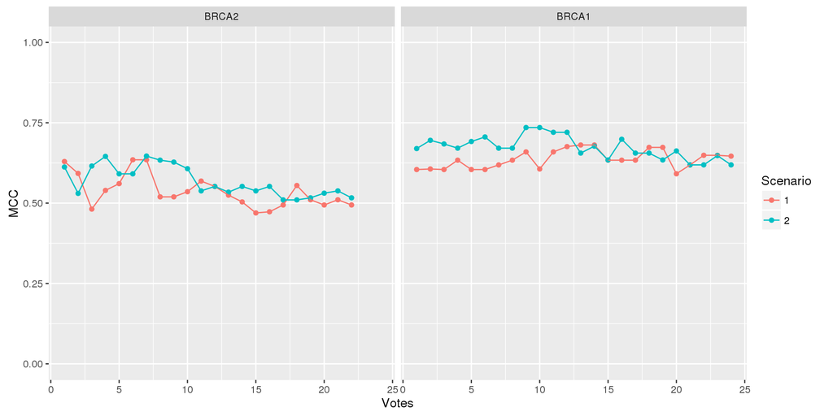

```r
FIG_S2_D<-NULL
FIG_S2_D$Votes <- nvm.mcc.1b$votes
FIG_S2_D$MCC   <- nvm.mcc.1b$mcc
FIG_S2_D$Gene  <- "BRCA1"
FIG_S2_D$Scenario <- 2


FIG_S2 <- rbind(data.frame(FIG_S2_A),data.frame(FIG_S2_B),data.frame(FIG_S2_C),data.frame(FIG_S2_D))
FIG_S2$Scenario<-as.factor(FIG_S2$Scenario)
ggplot(FIG_S2,aes(x=Votes,y=MCC,colour=Scenario))+geom_point()+geom_line()+ facet_grid(. ~ Gene)+ylim(0,1)
```

```r
ggsave("figures/FIG_S2.png",width=9,height=7, units="in",dpi = 600)
```

ROC analysis new models Add model names for new models

```r
modelnames2<-c(
"AlignGVGDPrior",
"CADDPhred",
"CADDRaw",
"CADDRawRankScore",
"CAROL",
"CONDEL",
"DannRankScore",
"DannScore",
"FathmmRankScore",
"FathmmScore",
"GerpNr",
"GerpRs",
"GerpRsRankScore",
"LRTConvertedRankScore",
"LRTScore",
"MetaLRRankScore",
"MetaLRScore",
"MetaSVMRankScore",
"MetaSVMScore",
"MutationAssessorRankScore",
"MutationAssessorScore",
"MutationTasterRankScore",
"MutationTasterScore",
"PERCH",
"PERCHnoMAF",
"Phastcons20wayMammalianRank",
"Phastcons7wayVertebrateRank",
"Phylop20wayMammalianRank",
"Phylop7wayVertebrateRank",
"Polyphen2HdivRankScore",
"Polyphen2HdivScore",
"Polyphen2HvarRankScore",
"Polyphen2HvarScore",
"PROVEANConvertedRankScore",
"PROVEANScore",
"SiftConvertedRankScore",
"SiftScore",
"Siphy29wayLogOddsRank",
"Vest3RankScore",
"Vest3Score",
"NewRFModel",
"NewVoteModel-Training",
"NewVoteModel-Validation",
"NewVoteModel-Both")
```

```r
#BRCA1
#Deleterious vs Intermediate/Neutral (Scenario 1)

v2a.41 <- optimal.cutpoints(X="rf_prob_del",status="hdr_del",
                            tag.healthy=0,methods=c("SpEqualSe"),
                                      control = control.cutpoints(ci.SeSp = "AgrestiCoull"),
                                      ci.fit=TRUE,data=vus.brca2..)


v2a.42 <- optimal.cutpoints(X="sum_del_6",status="hdr_del",
                            tag.healthy=0,methods=c("SpEqualSe"),
                                      control = control.cutpoints(ci.SeSp = "AgrestiCoull"),
                                      ci.fit=TRUE,data=brca2.votes.train)

v2a.43 <- optimal.cutpoints(X="sum_del_6",status="hdr_del",
                            tag.healthy=0,methods=c("SpEqualSe"),
                                      control = control.cutpoints(ci.SeSp = "AgrestiCoull"),
                                      ci.fit=TRUE,data=brca2.votes.test)

v2a.44 <- optimal.cutpoints(X="sum_del_6",status="hdr_del",
                            tag.healthy=0,methods=c("SpEqualSe"),
                                      control = control.cutpoints(ci.SeSp = "AgrestiCoull"),
                                      ci.fit=TRUE,data=brca2)


# Extract performance statistics for new models

list.new <- list(v2a.41, v2a.42, v2a.43, v2a.44)
names(list.new) <- c("v2a.41","v2a.42","v2a.43","v2a.44")

fn <- matrix(NA,nrow=4,ncol=1)
fp <- matrix(NA,nrow=4,ncol=1)
nh <- matrix(NA,nrow=4,ncol=1)
nd <- matrix(NA,nrow=4,ncol=1)
tp <- matrix(NA,nrow=4,ncol=1)
tn <- matrix(NA,nrow=4,ncol=1)
mcc <- matrix(NA,nrow=4,ncol=1)
cutoff <- matrix(NA,nrow=4,ncol=1)
auc <- matrix(NA,nrow=4,ncol=3)
sens <- matrix(NA,nrow=4,ncol=3)
spec <- matrix(NA,nrow=4,ncol=3)

for (i in 1:length(list.new)) {

auc[i,] <- list.new[[i]]$SpEqualSe[[1]]$measures.acc$AUC
sens[i,] <- list.new[[i]]$SpEqualSe[[1]]$optimal.cutoff$Se[c(1:3)]
spec[i,] <- list.new[[i]]$SpEqualSe[[1]]$optimal.cutoff$Sp[c(1:3)]
fn[i,1] <- list.new[[i]]$SpEqualSe[[1]]$optimal.cutoff$FN[1]
fp[i,1] <- list.new[[i]]$SpEqualSe[[1]]$optimal.cutoff$FP[1]
nh[i,1] <- list.new[[i]]$SpEqualSe[[1]]$measures.acc$n$h
nd[i,1] <- list.new[[i]]$SpEqualSe[[1]]$measures.acc$n$d
tp[i,1] <- nd[i,] - fn[i,]
tn[i,1] <- nh[i,] - fp[i,]

cutoff[i,1] <- list.new[[i]]$SpEqualSe[[1]]$optimal.cutoff$cutoff

mcc[i,1] <- (tp[i,]*tn[i,]-fp[i,]*fn[i,])/sqrt((tp[i,]+fp[i,])*
            (tp[i,]+fn[i,])*(tn[i,]+fp[i,])*(tn[i,]+fn[i,]))

brca2a.new.models <- data.frame(modelnames2[41:44],cutoff,sens,spec,auc,fn,fp,tp,tn,mcc,
                                stringsAsFactors = FALSE)
colnames(brca2a.new.models) <- c("model","cutpoint","sens","sens.lcl","sens.ucl","spec",
                             "spec.lcl","spec.ucl","auc","auc.lcl","auc.ucl","FN","FP",
                             "TP","TN","mcc")

}

#kable(brca2a.new.models, caption='Performance of New Models for BRCA2, Scenario 1')
brca2a.new.models$Gene="BRCA2"
brca2a.new.models$Scenario=1


ST4 <-brca2a.new.models
```

BRCA2: Deleterious/Intermediate vs Neutral (Scenario2)

```r
v2b.41 <- optimal.cutpoints(X="rf_prob_delint",status="hdr_not_neutral",
                            tag.healthy=0,methods=c("SpEqualSe"),
                                      control = control.cutpoints(ci.SeSp = "AgrestiCoull"),
                                      ci.fit=TRUE,data=vus.brca2..)

v2b.42 <- optimal.cutpoints(X="sum_nn_7",status="hdr_not_neutral",
                            tag.healthy=0,methods=c("SpEqualSe"),
                                      control = control.cutpoints(ci.SeSp = "AgrestiCoull"),
                                      ci.fit=TRUE,data=brca2.votes.train)

v2b.43 <- optimal.cutpoints(X="sum_nn_7",status="hdr_not_neutral",
                            tag.healthy=0,methods=c("SpEqualSe"),
                                      control = control.cutpoints(ci.SeSp = "AgrestiCoull"),
                                      ci.fit=TRUE,data=brca2.votes.test)

v2b.44 <- optimal.cutpoints(X="sum_nn_7",status="hdr_not_neutral",
                            tag.healthy=0,methods=c("SpEqualSe"),
                                      control = control.cutpoints(ci.SeSp = "AgrestiCoull"),
                                      ci.fit=TRUE,data=brca2)


# Extract performance statistics for new models

list.new <- list(v2b.41, v2b.42, v2b.43, v2b.44)
names(list.new) <- c("v2b.41","v2b.42","v2b.43","v2b.44")

fn <- matrix(NA,nrow=4,ncol=1)
fp <- matrix(NA,nrow=4,ncol=1)
nh <- matrix(NA,nrow=4,ncol=1)
nd <- matrix(NA,nrow=4,ncol=1)
tp <- matrix(NA,nrow=4,ncol=1)
tn <- matrix(NA,nrow=4,ncol=1)
mcc <- matrix(NA,nrow=4,ncol=1)
cutoff <- matrix(NA,nrow=4,ncol=1)
auc <- matrix(NA,nrow=4,ncol=3)
sens <- matrix(NA,nrow=4,ncol=3)
spec <- matrix(NA,nrow=4,ncol=3)

for (i in 1:length(list.new)) {

auc[i,] <- list.new[[i]]$SpEqualSe[[1]]$measures.acc$AUC
sens[i,] <- list.new[[i]]$SpEqualSe[[1]]$optimal.cutoff$Se[c(1:3)]
spec[i,] <- list.new[[i]]$SpEqualSe[[1]]$optimal.cutoff$Sp[c(1:3)]
fn[i,1] <- list.new[[i]]$SpEqualSe[[1]]$optimal.cutoff$FN[1]
fp[i,1] <- list.new[[i]]$SpEqualSe[[1]]$optimal.cutoff$FP[1]
nh[i,1] <- list.new[[i]]$SpEqualSe[[1]]$measures.acc$n$h
nd[i,1] <- list.new[[i]]$SpEqualSe[[1]]$measures.acc$n$d
tp[i,1] <- nd[i,] - fn[i,]
tn[i,1] <- nh[i,] - fp[i,]

cutoff[i,1] <- list.new[[i]]$SpEqualSe[[1]]$optimal.cutoff$cutoff

mcc[i,1] <- (tp[i,]*tn[i,]-fp[i,]*fn[i,])/sqrt((tp[i,]+fp[i,])*
            (tp[i,]+fn[i,])*(tn[i,]+fp[i,])*(tn[i,]+fn[i,]))

brca2b.new.models <- data.frame(modelnames2[41:44],cutoff,sens,spec,auc,fn,fp,tp,tn,mcc,
                                stringsAsFactors = FALSE)
colnames(brca2b.new.models) <- c("model","cutpoint","sens","sens.lcl","sens.ucl","spec",
                             "spec.lcl","spec.ucl","auc","auc.lcl","auc.ucl","FN","FP",
                             "TP","TN","mcc")

}

#kable(brca2b.new.models, caption='Performance of New Models for BRCA2, Scenario 2')
brca2b.new.models$Gene="BRCA2"
brca2b.new.models$Scenario=2
ST4<-rbind(brca2b.new.models,ST4)
```

BRCA1: Deleterious vs Intermediate/Neutral (Scenario 1)

```r
v1a.41 <- optimal.cutpoints(X="rf_prob_del",status="hdr_del",
                            tag.healthy=0,methods=c("SpEqualSe"),
                                      control = control.cutpoints(ci.SeSp = "AgrestiCoull"),
                                      ci.fit=TRUE,data=vus.brca1..)

v1a.42 <- optimal.cutpoints(X="sum_del_13",status="hdr_del",
                            tag.healthy=0,methods=c("SpEqualSe"),
                                      control = control.cutpoints(ci.SeSp = "AgrestiCoull"),
                            ci.fit=TRUE,data=brca1.votes.train)

v1a.43 <- optimal.cutpoints(X="sum_del_13",status="hdr_del",
                            tag.healthy=0,methods=c("MinValueSp"),
                                      ci.fit=TRUE,data=brca1.votes.test)

v1a.44 <- optimal.cutpoints(X="sum_del_13",status="hdr_del",
                            tag.healthy=0,methods=c("MinValueSp"),
                                      control = control.cutpoints(ci.SeSp = "AgrestiCoull",valueSp=0.89),
                            ci.fit=TRUE,data=brca1)

# Extract performance statistics for new models

list.new <- list(v1a.41, v1a.42, v1a.43, v1a.44)
names(list.new) <- c("v1a.41","v1a.42","v1a.43","v1a.44")

fn <- matrix(NA,nrow=4,ncol=1)
fp <- matrix(NA,nrow=4,ncol=1)
nh <- matrix(NA,nrow=4,ncol=1)
nd <- matrix(NA,nrow=4,ncol=1)
tp <- matrix(NA,nrow=4,ncol=1)
tn <- matrix(NA,nrow=4,ncol=1)
mcc <- matrix(NA,nrow=4,ncol=1)
cutoff <- matrix(NA,nrow=4,ncol=1)
auc <- matrix(NA,nrow=4,ncol=3)
sens <- matrix(NA,nrow=4,ncol=3)
spec <- matrix(NA,nrow=4,ncol=3)

for (i in 1:1) {

auc[i,] <- list.new[[i]]$SpEqualSe[[1]]$measures.acc$AUC
sens[i,] <- list.new[[i]]$SpEqualSe[[1]]$optimal.cutoff$Se[c(1,3,5)]
spec[i,] <- list.new[[i]]$SpEqualSe[[1]]$optimal.cutoff$Sp[c(1,3,5)]
fn[i,1] <- list.new[[i]]$SpEqualSe[[1]]$optimal.cutoff$FN[1]
fp[i,1] <- list.new[[i]]$SpEqualSe[[1]]$optimal.cutoff$FP[1]
nh[i,1] <- list.new[[i]]$SpEqualSe[[1]]$measures.acc$n$h
nd[i,1] <- list.new[[i]]$SpEqualSe[[1]]$measures.acc$n$d
tp[i,1] <- nd[i,] - fn[i,]
tn[i,1] <- nh[i,] - fp[i,]

cutoff[i,1] <- list.new[[i]]$SpEqualSe[[1]]$optimal.cutoff$cutoff[1]

mcc[i,1] <- (tp[i,]*tn[i,]-fp[i,]*fn[i,])/sqrt((tp[i,]+fp[i,])*
            (tp[i,]+fn[i,])*(tn[i,]+fp[i,])*(tn[i,]+fn[i,]))

brca1a.new.models.1 <- data.frame(cutoff,sens,spec,auc,fn,fp,tp,tn,mcc,
                                stringsAsFactors = FALSE)

}

for (i in 2:2) {

auc[i,] <- list.new[[i]]$SpEqualSe[[1]]$measures.acc$AUC
sens[i,] <- list.new[[i]]$SpEqualSe[[1]]$optimal.cutoff$Se[c(1:3)]
spec[i,] <- list.new[[i]]$SpEqualSe[[1]]$optimal.cutoff$Sp[c(1:3)]
fn[i,1] <- list.new[[i]]$SpEqualSe[[1]]$optimal.cutoff$FN[1]
fp[i,1] <- list.new[[i]]$SpEqualSe[[1]]$optimal.cutoff$FP[1]
nh[i,1] <- list.new[[i]]$SpEqualSe[[1]]$measures.acc$n$h
nd[i,1] <- list.new[[i]]$SpEqualSe[[1]]$measures.acc$n$d
tp[i,1] <- nd[i,] - fn[i,]
tn[i,1] <- nh[i,] - fp[i,]

cutoff[i,1] <- list.new[[i]]$SpEqualSe[[1]]$optimal.cutoff$cutoff

mcc[i,1] <- (tp[i,]*tn[i,]-fp[i,]*fn[i,])/sqrt((tp[i,]+fp[i,])*
            (tp[i,]+fn[i,])*(tn[i,]+fp[i,])*(tn[i,]+fn[i,]))

brca1a.new.models.2 <- data.frame(cutoff,sens,spec,auc,fn,fp,tp,tn,mcc,
                                stringsAsFactors = FALSE)

}

for (i in 3:4) {

auc[i,] <- list.new[[i]]$MinValueSp[[1]]$measures.acc$AUC
sens[i,] <- list.new[[i]]$MinValueSp[[1]]$optimal.cutoff$Se[c(1:3)]
spec[i,] <- list.new[[i]]$MinValueSp[[1]]$optimal.cutoff$Sp[c(1:3)]
fn[i,1] <- list.new[[i]]$MinValueSp[[1]]$optimal.cutoff$FN[1]
fp[i,1] <- list.new[[i]]$MinValueSp[[1]]$optimal.cutoff$FP[1]
nh[i,1] <- list.new[[i]]$MinValueSp[[1]]$measures.acc$n$h
nd[i,1] <- list.new[[i]]$MinValueSp[[1]]$measures.acc$n$d
tp[i,1] <- nd[i,] - fn[i,]
tn[i,1] <- nh[i,] - fp[i,]

cutoff[i,1] <- list.new[[i]]$MinValueSp[[1]]$optimal.cutoff$cutoff

mcc[i,1] <- (tp[i,]*tn[i,]-fp[i,]*fn[i,])/sqrt((tp[i,]+fp[i,])*
            (tp[i,]+fn[i,])*(tn[i,]+fp[i,])*(tn[i,]+fn[i,]))

brca1a.new.models.3 <- data.frame(cutoff,sens,spec,auc,fn,fp,tp,tn,mcc,
                                stringsAsFactors = FALSE)
}


brca1a.new.models <- cbind(modelnames2[41:44],brca1a.new.models.3)
colnames(brca1a.new.models) <- c("model","cutpoint","sens","sens.lcl","sens.ucl","spec",
                             "spec.lcl","spec.ucl","auc","auc.lcl","auc.ucl","FN","FP",
                             "TP","TN","mcc")

#kable(brca1a.new.models, caption='Performance of New Models for BRCA1, Scenario 1')
brca1a.new.models$Gene="BRCA1"
brca1a.new.models$Scenario=1
ST4<-rbind(brca1a.new.models,ST4)
```

BRCA1 - Deleterious/Intermediate vs Neutral (Scenario 2)

```r
#BRCA1 - Deleterious/Intermediate vs Neutral (Scenario 2)
v1b.41 <- optimal.cutpoints(X="rf_prob_delint",status="hdr_not_neutral",
                            tag.healthy=0,methods=c("SpEqualSe"),
                                      control = control.cutpoints(ci.SeSp = "AgrestiCoull"),
                                      ci.fit=TRUE,data=vus.brca1..)

v1b.42 <- optimal.cutpoints(X="sum_nn_9",status="hdr_not_neutral",
                            tag.healthy=0,methods=c("SpEqualSe"),
                                      control = control.cutpoints(ci.SeSp = "AgrestiCoull"),
                                      ci.fit=TRUE,data=brca1.votes.train)

v1b.43 <- optimal.cutpoints(X="sum_nn_9",status="hdr_not_neutral",
                            tag.healthy=0,methods=c("MinValueSp"),
                                      control = control.cutpoints(ci.SeSp = "AgrestiCoull",valueSp=0.9),
                                      ci.fit=TRUE,data=brca1.votes.test)

v1b.44 <- optimal.cutpoints(X="sum_nn_9",status="hdr_not_neutral",
                            tag.healthy=0,methods=c("MinValueSp"),
                                      control = control.cutpoints(ci.SeSp = "AgrestiCoull",valueSp=0.85),
                                      ci.fit=TRUE,data=brca1)

list.new <- list(v1b.41, v1b.42, v1b.43, v1b.44)
names(list.new) <- c("v1b.41","v1b.42","v1b.43","v1b.44")

fn <- matrix(NA,nrow=4,ncol=1)
fp <- matrix(NA,nrow=4,ncol=1)
nh <- matrix(NA,nrow=4,ncol=1)
nd <- matrix(NA,nrow=4,ncol=1)
tp <- matrix(NA,nrow=4,ncol=1)
tn <- matrix(NA,nrow=4,ncol=1)
mcc <- matrix(NA,nrow=4,ncol=1)
cutoff <- matrix(NA,nrow=4,ncol=1)
auc <- matrix(NA,nrow=4,ncol=3)
sens <- matrix(NA,nrow=4,ncol=3)
spec <- matrix(NA,nrow=4,ncol=3)

for (i in 1:2) {

auc[i,] <- list.new[[i]]$SpEqualSe[[1]]$measures.acc$AUC
sens[i,] <- list.new[[i]]$SpEqualSe[[1]]$optimal.cutoff$Se[c(1:3)]
spec[i,] <- list.new[[i]]$SpEqualSe[[1]]$optimal.cutoff$Sp[c(1:3)]
fn[i,1] <- list.new[[i]]$SpEqualSe[[1]]$optimal.cutoff$FN[1]
fp[i,1] <- list.new[[i]]$SpEqualSe[[1]]$optimal.cutoff$FP[1]
nh[i,1] <- list.new[[i]]$SpEqualSe[[1]]$measures.acc$n$h
nd[i,1] <- list.new[[i]]$SpEqualSe[[1]]$measures.acc$n$d
tp[i,1] <- nd[i,] - fn[i,]
tn[i,1] <- nh[i,] - fp[i,]

cutoff[i,1] <- list.new[[i]]$SpEqualSe[[1]]$optimal.cutoff$cutoff[1]

mcc[i,1] <- (tp[i,]*tn[i,]-fp[i,]*fn[i,])/sqrt((tp[i,]+fp[i,])*
            (tp[i,]+fn[i,])*(tn[i,]+fp[i,])*(tn[i,]+fn[i,]))

brca1a.new.models.1 <- data.frame(cutoff,sens,spec,auc,fn,fp,tp,tn,mcc,
                                stringsAsFactors = FALSE)
}


for (i in 3:4) {

auc[i,] <- list.new[[i]]$MinValueSp[[1]]$measures.acc$AUC
sens[i,] <- list.new[[i]]$MinValueSp[[1]]$optimal.cutoff$Se[c(1:3)]
spec[i,] <- list.new[[i]]$MinValueSp[[1]]$optimal.cutoff$Sp[c(1:3)]
fn[i,1] <- list.new[[i]]$MinValueSp[[1]]$optimal.cutoff$FN[1]
fp[i,1] <- list.new[[i]]$MinValueSp[[1]]$optimal.cutoff$FP[1]
nh[i,1] <- list.new[[i]]$MinValueSp[[1]]$measures.acc$n$h
nd[i,1] <- list.new[[i]]$MinValueSp[[1]]$measures.acc$n$d
tp[i,1] <- nd[i,] - fn[i,]
tn[i,1] <- nh[i,] - fp[i,]

cutoff[i,1] <- list.new[[i]]$MinValueSp[[1]]$optimal.cutoff$cutoff

mcc[i,1] <- (tp[i,]*tn[i,]-fp[i,]*fn[i,])/sqrt((tp[i,]+fp[i,])*
            (tp[i,]+fn[i,])*(tn[i,]+fp[i,])*(tn[i,]+fn[i,]))

brca1b.new.models.2 <- data.frame(cutoff,sens,spec,auc,fn,fp,tp,tn,mcc,
                                stringsAsFactors = FALSE)
}


brca1b.new.models <- cbind(modelnames2[41:44],brca1b.new.models.2)
colnames(brca1b.new.models) <- c("model","cutpoint","sens","sens.lcl","sens.ucl","spec",
                             "spec.lcl","spec.ucl","auc","auc.lcl","auc.ucl","FN","FP",
                             "TP","TN","mcc")

#kable(brca1b.new.models, caption='Performance of New Models for BRCA1, Scenario 2')
brca1b.new.models$Gene="BRCA1"
brca1b.new.models$Scenario=2
ST4<-rbind(brca1b.new.models,ST4)
```

Appending new methods to Table S4 and sorting by MCC

```r
ST4 <- rbind(ST4_BRCA1_S1,ST4_BRCA1_S2,ST4_BRCA2_S1,ST4_BRCA2_S2,ST4)
ST4 <- ST4[order(ST4$mcc,decreasing = T),]
```

# Table 2

### Performance of in silico prediction models with optimized thresholds for classification of BRCA1 and BRCA2 missense variants (Subset of table S4)

```r
brca1_idx = which(ST4$model != "NewVoteModel-Training" &
                    ST4$model != "NewVoteModel-Both" &
                    ST4$Gene=="BRCA1" &
                    ST4$Scenario ==1)[1:12]
brca2_idx = which(ST4$model != "NewVoteModel-Training" &
                    ST4$model != "NewVoteModel-Both" &
                    ST4$Gene=="BRCA2" &
                    ST4$Scenario ==1)[1:12]
tmp_table <-ST4[c(brca1_idx,brca2_idx),]
tmp_table = tmp_table[which(tmp_table$Scenario==1),]
tmp_table$AUC <-paste(round(tmp_table$auc,2)," (",round(tmp_table$auc.lcl,3),"-",round(tmp_table$auc.ucl,3),")",sep="")
tmp_table$FN_FP_TP_TN<-paste(tmp_table$FN,tmp_table$FP,tmp_table$TP,tmp_table$TN,sep=" / ")
tmp_table$ORDER=1
tmp_table$cutpoint<-round(tmp_table$cutpoint,2)
tmp_table$ORDER[which(tmp_table$Gene=="BRCA2")]=0
TABLE_2 = unique(tmp_table[order(tmp_table$ORDER, tmp_table$mcc,decreasing=T),c("Gene","model","cutpoint","AUC","FN_FP_TP_TN","mcc")])
kable(TABLE_2,row.names = F)
```

| Gene | model | cutpoint | AUC | FN_FP_TP_TN | mcc |
| --- | --- | --- | --- | --- | --- |
| BRCA1 | NewVoteModel-Validation | 9.00 | 0.94 (0.897-0.983) | 5 / 8 / 25 / 79 | 0.719 |
| BRCA1 | Vest3Rankscore | 0.86 | 0.9 (0.849-0.95) | 8 / 24 / 51 / 153 | 0.678 |
| BRCA1 | Vest3Score | 0.87 | 0.9 (0.849-0.95) | 8 / 24 / 51 / 153 | 0.678 |
| BRCA1 | NewRFModel | 0.30 | 0.92 (0.879-0.96) | 8 / 26 / 51 / 151 | 0.663 |
| BRCA1 | a_gvgd_prior | 0.29 | 0.88 (0.829-0.931) | 7 / 37 / 54 / 150 | 0.614 |
| BRCA1 | PERCH_noMAF | 0.21 | 0.87 (0.814-0.924) | 10 / 31 / 51 / 156 | 0.614 |
| BRCA1 | PERCH | 0.24 | 0.87 (0.819-0.922) | 10 / 32 / 51 / 155 | 0.607 |
| BRCA1 | Polyphen2HvarRankscore | 0.92 | 0.89 (0.845-0.93) | 11 / 30 / 48 / 147 | 0.593 |
| BRCA1 | Polyphen2HvarScore | 1.00 | 0.89 (0.845-0.93) | 11 / 30 / 48 / 147 | 0.593 |
| BRCA1 | MetasvmRankscore | 0.91 | 0.89 (0.844-0.928) | 11 / 34 / 48 / 143 | 0.565 |
| BRCA1 | MetasvmScore | 0.52 | 0.89 (0.844-0.928) | 11 / 34 / 48 / 143 | 0.565 |
| BRCA1 | SiftConvertedRankscore | 0.91 | 0.83 (0.786-0.871) | 5 / 52 / 54 / 125 | 0.541 |
| BRCA2 | NewVoteModel-Validation | 4.00 | 0.89 (0.826-0.963) | 6 / 9 / 29 / 59 | 0.683 |
| BRCA2 | PERCH | 0.30 | 0.89 (0.847-0.939) | 11 / 21 / 60 / 115 | 0.672 |
| BRCA2 | PERCH_noMAF | 0.27 | 0.88 (0.832-0.929) | 12 / 23 / 59 / 113 | 0.642 |
| BRCA2 | NewRFModel | 0.37 | 0.9 (0.843-0.947) | 12 / 24 / 59 / 111 | 0.633 |
| BRCA2 | MetasvmRankscore | 0.93 | 0.87 (0.824-0.923) | 15 / 29 / 56 / 107 | 0.555 |
| BRCA2 | MetasvmScore | 0.70 | 0.87 (0.824-0.923) | 15 / 29 / 56 / 107 | 0.555 |
| BRCA2 | MetalrRankscore | 0.92 | 0.87 (0.823-0.922) | 16 / 30 / 55 / 106 | 0.535 |
| BRCA2 | MetalrScore | 0.77 | 0.87 (0.823-0.922) | 16 / 30 / 55 / 106 | 0.535 |
| BRCA2 | Vest3Rankscore | 0.80 | 0.83 (0.776-0.893) | 16 / 30 / 55 / 106 | 0.535 |
| BRCA2 | Vest3Score | 0.81 | 0.83 (0.776-0.893) | 16 / 30 / 55 / 106 | 0.535 |
| BRCA2 | Polyphen2HvarRankscore | 0.97 | 0.81 (0.757-0.862) | 15 / 35 / 56 / 100 | 0.507 |
| BRCA2 | Polyphen2HvarScore | 1.00 | 0.81 (0.757-0.862) | 15 / 35 / 56 / 100 | 0.507 |

```r
write.table(TABLE_2,file="tables/Table_2.tsv",row.names = F,col.names = T,sep="\t")
```

# Figure S3

### Receiver operating characteristic (ROC) curves for the NVM model applied to the entire data set using rules for BRCA1 and BRCA2 genes.

Assemble stats for NVM

```r
# Numbers for NVM ROC figure
roc2a.nvm <- prediction(brca2$sum_del_6,brca2$hdr_del)
perf2a.nvm <- performance(roc2a.nvm,"tpr","fpr")
x_val <- unlist(perf2a.nvm@x.values)
y_val <- unlist(perf2a.nvm@y.values)
gene  <- rep("BRCA2",length(x_val))
Scenario  <- rep("Scenario 1",length(x_val))
tmp<- data.frame(FPR=x_val,TPR=y_val,Gene=gene,Scenario)

roc2b.nvm <- prediction(brca2$sum_nn_7,brca2$hdr_not_neutral)
perf2b.nvm <- performance(roc2b.nvm,"tpr","fpr")
x_val <- unlist(perf2b.nvm@x.values)
y_val <- unlist(perf2b.nvm@y.values)
gene  <- rep("BRCA2",length(x_val))
Scenario  <- rep("Scenario 2",length(x_val))
tmp<- rbind(tmp,data.frame(FPR=x_val,TPR=y_val,Gene=gene,Scenario))

roc1a.nvm <- prediction(brca1$sum_del_13,brca1$hdr_del)
perf1a.nvm <- performance(roc1a.nvm,"tpr","fpr")
x_val <- unlist(perf1a.nvm@x.values)
y_val <- unlist(perf1a.nvm@y.values)
gene  <- rep("BRCA1",length(x_val))
Scenario  <- rep("Scenario 1",length(x_val))
tmp<- rbind(tmp,data.frame(FPR=x_val,TPR=y_val,Gene=gene,Scenario))

roc1b.nvm <- prediction(brca1$sum_nn_9,brca1$hdr_not_neutral)
perf1b.nvm <- performance(roc1b.nvm,"tpr","fpr")
x_val <- unlist(perf1b.nvm@x.values)
y_val <- unlist(perf1b.nvm@y.values)
gene  <- rep("BRCA1",length(x_val))
Scenario  <- rep("Scenario 2",length(x_val))
tmp<- rbind(tmp,data.frame(FPR=x_val,TPR=y_val,Gene=gene,Scenario))
tmp$Model <-"NVM"
```

Assemble stats for RF

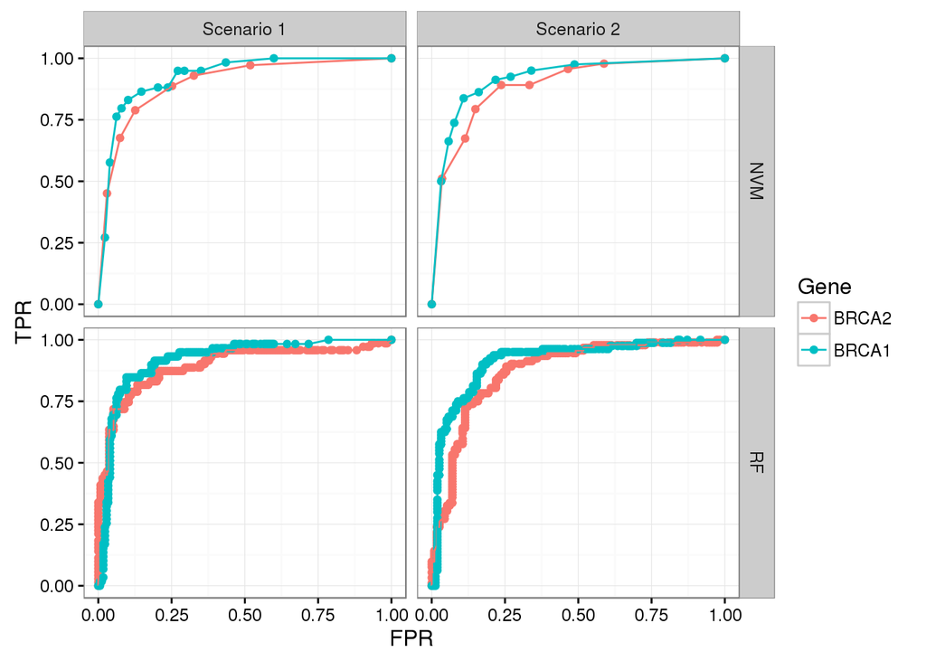

```r
# Numbers for RF ROC figure
roc2a.rf <- prediction(vus.brca2..$rf_prob_del,vus.brca2..$hdr_del)
perf2a.rf<- performance(roc2a.rf,"tpr","fpr")
x_val <- unlist(perf2a.rf@x.values)
y_val <- unlist(perf2a.rf@y.values)
gene  <- rep("BRCA2",length(x_val))
Scenario  <- rep("Scenario 1",length(x_val))
tmp2<- data.frame(FPR=x_val,TPR=y_val,Gene=gene,Scenario)

roc2b.rf <- prediction(vus.brca2..$rf_prob_delint,vus.brca2..$hdr_not_neutral)
perf2b.rf <- performance(roc2b.rf,"tpr","fpr")
x_val <- unlist(perf2b.rf@x.values)
y_val <- unlist(perf2b.rf@y.values)
gene  <- rep("BRCA2",length(x_val))
Scenario  <- rep("Scenario 2",length(x_val))
tmp2<- rbind(tmp2,data.frame(FPR=x_val,TPR=y_val,Gene=gene,Scenario))

roc1a.rf <- prediction(vus.brca1..$rf_prob_del,vus.brca1..$hdr_del)
perf1a.rf <- performance(roc1a.rf,"tpr","fpr")
x_val <- unlist(perf1a.rf@x.values)
y_val <- unlist(perf1a.rf@y.values)
gene  <- rep("BRCA1",length(x_val))
Scenario  <- rep("Scenario 1",length(x_val))
tmp2<- rbind(tmp2,data.frame(FPR=x_val,TPR=y_val,Gene=gene,Scenario))


roc1b.rf <- prediction(vus.brca1..$rf_prob_delint,vus.brca1..$hdr_not_neutral)
perf1b.rf <- performance(roc1b.rf,"tpr","fpr")
x_val <- unlist(perf1b.rf@x.values)
y_val <- unlist(perf1b.rf@y.values)
gene  <- rep("BRCA1",length(x_val))
Scenario  <- rep("Scenario 2",length(x_val))
tmp2<- rbind(tmp2,data.frame(FPR=x_val,TPR=y_val,Gene=gene,Scenario))
tmp2$Model <- "RF"

tmp_SF3 <- rbind(tmp,tmp2)
ggplot(tmp_SF3,aes(x=FPR,y=TPR,colour=Gene))+geom_point()+geom_line()+facet_grid(Model ~ Scenario)+theme_bw()
```

```r
ggsave("figures/FIG_S3.png",height = 9,width = 5,units="in",dpi = 600)
```

# Table S4

### Sensitivity, Specificity, AUC, and MCC for each gene and each Scenario.

```r
brca2a.models.$Gene="BRCA2"
brca2a.models.$Scenario="1"
brca2a.output <- rbind(brca2a.models., brca2a.new.models)

brca2a.output. <- cbind(rep(2,44),rep(1,44),brca2a.output)
colnames(brca2a.output.) <- c("Gene","Scenario","model","cutpoint","sens","sens.lcl","sens.ucl","spec",
                             "spec.lcl","spec.ucl","auc","auc.lcl","auc.ucl","FN","FP",
                             "TP","TN","mcc")
brca2a.output.$Gene="BRCA2"

brca2b.models.$Gene="BRCA2"
brca2b.models.$Scenario="2"
brca2b.output <- rbind(brca2b.models., brca2b.new.models)
brca2b.output. <- cbind(rep(2,44),rep(2,44),brca2b.output)
colnames(brca2b.output.) <- c("Gene","Scenario","model","cutpoint","sens","sens.lcl","sens.ucl","spec",
                             "spec.lcl","spec.ucl","auc","auc.lcl","auc.ucl","FN","FP",
                             "TP","TN","mcc")
brca2b.output.$Gene="BRCA2"

brca1a.models.$Gene="BRCA1"
brca1a.models.$Scenario="1"
brca1a.output <- rbind(brca1a.models., brca1a.new.models)
brca1a.output. <- cbind(rep(1,44),rep(1,44),brca1a.output)
colnames(brca1a.output.) <- c("Gene","Scenario","model","cutpoint","sens","sens.lcl","sens.ucl","spec",
                             "spec.lcl","spec.ucl","auc","auc.lcl","auc.ucl","FN","FP",
                             "TP","TN","mcc")
brca1a.output.$Gene="BRCA1"

brca1b.models.$Gene="BRCA1"
brca1b.models.$Scenario="2"
brca1b.output <- rbind(brca1b.models., brca1b.new.models)
brca1b.output. <- cbind(rep(1,44),rep(2,44),brca1b.output)
colnames(brca1b.output.) <- c("Gene","Scenario","model","cutpoint","sens","sens.lcl","sens.ucl","spec",
                             "spec.lcl","spec.ucl","auc","auc.lcl","auc.ucl","FN","FP",
                             "TP","TN","mcc")
brca1b.output.$Gene="BRCA1"

ST4 <- rbind(brca2a.new.models,brca2b.new.models,brca1a.new.models,brca1b.new.models,ST4)
```

```r
kable(ST4)
```

|  | model | cutpoint | sens | sens.lcl | sens.ucl | spec | spec.lcl | spec.ucl | auc | auc.lcl | auc.ucl | FN | FP | TP | TN | mcc | Gene | Scenario |
| --- | --- | --- | --- | --- | --- | --- | --- | --- | --- | --- | --- | --- | --- | --- | --- | --- | --- | --- |
| 1 | NewRFModel | 0.371 | 0.831 | 0.727 | 0.901 | 0.822 | 0.749 | 0.878 | 0.895 | 0.843 | 0.947 | 12 | 24 | 59 | 111 | 0.633 | BRCA2 | 1 |
| 2 | NewVoteModel-Training | 4.000 | 0.750 | 0.589 | 0.862 | 0.881 | 0.782 | 0.938 | 0.904 | 0.848 | 0.961 | 9 | 8 | 27 | 59 | 0.635 | BRCA2 | 1 |
| 3 | NewVoteModel-Validation | 4.000 | 0.829 | 0.673 | 0.919 | 0.868 | 0.767 | 0.929 | 0.894 | 0.826 | 0.963 | 6 | 9 | 29 | 59 | 0.683 | BRCA2 | 1 |
| 4 | NewVoteModel-Both | 4.000 | 0.789 | 0.680 | 0.868 | 0.874 | 0.808 | 0.920 | 0.900 | 0.856 | 0.944 | 15 | 17 | 56 | 118 | 0.659 | BRCA2 | 1 |
| 5 | NewRFModel | 0.437 | 0.804 | 0.712 | 0.873 | 0.798 | 0.715 | 0.862 | 0.873 | 0.824 | 0.922 | 18 | 23 | 74 | 91 | 0.600 | BRCA2 | 2 |
| 6 | NewVoteModel-Training | 5.000 | 0.804 | 0.668 | 0.893 | 0.842 | 0.726 | 0.915 | 0.890 | 0.829 | 0.951 | 9 | 9 | 37 | 48 | 0.646 | BRCA2 | 2 |
| 7 | NewVoteModel-Validation | 5.000 | 0.783 | 0.644 | 0.877 | 0.860 | 0.747 | 0.927 | 0.887 | 0.821 | 0.953 | 10 | 8 | 36 | 49 | 0.645 | BRCA2 | 2 |
| 8 | NewVoteModel-Both | 5.000 | 0.793 | 0.700 | 0.864 | 0.851 | 0.774 | 0.905 | 0.890 | 0.845 | 0.934 | 19 | 17 | 73 | 97 | 0.646 | BRCA2 | 2 |
| 9 | NewRFModel | 0.298 | 0.864 | 0.755 | 0.930 | 0.853 | 0.793 | 0.898 | 0.920 | 0.879 | 0.960 | 8 | 26 | 51 | 151 | 0.663 | BRCA1 | 1 |
| 10 | NewVoteModel-Training | 9.000 | 0.828 | 0.655 | 0.924 | 0.889 | 0.807 | 0.939 | 0.913 | 0.856 | 0.971 | 5 | 10 | 24 | 80 | 0.681 | BRCA1 | 1 |
| 11 | NewVoteModel-Validation | 9.000 | 0.833 | 0.653 | 0.944 | 0.908 | 0.827 | 0.959 | 0.940 | 0.897 | 0.983 | 5 | 8 | 25 | 79 | 0.719 | BRCA1 | 1 |
| 12 | NewVoteModel-Both | 9.000 | 0.831 | 0.715 | 0.905 | 0.898 | 0.845 | 0.935 | 0.926 | 0.891 | 0.961 | 10 | 18 | 49 | 159 | 0.700 | BRCA1 | 1 |
| 13 | NewRFModel | 0.378 | 0.850 | 0.756 | 0.912 | 0.846 | 0.781 | 0.894 | 0.915 | 0.875 | 0.955 | 12 | 24 | 68 | 132 | 0.676 | BRCA1 | 2 |
| 14 | NewVoteModel-Training | 6.000 | 0.900 | 0.769 | 0.960 | 0.861 | 0.768 | 0.920 | 0.911 | 0.855 | 0.967 | 4 | 11 | 36 | 68 | 0.735 | BRCA1 | 2 |
| 15 | NewVoteModel-Validation | 6.000 | 0.775 | 0.625 | 0.877 | 0.922 | 0.840 | 0.964 | 0.923 | 0.871 | 0.975 | 9 | 6 | 31 | 71 | 0.711 | BRCA1 | 2 |
| 16 | NewVoteModel-Both | 6.000 | 0.838 | 0.742 | 0.903 | 0.891 | 0.832 | 0.931 | 0.918 | 0.880 | 0.956 | 13 | 17 | 67 | 139 | 0.720 | BRCA1 | 2 |
| 162 | NewVoteModel-Training | 6.000 | 0.900 | 0.769 | 0.960 | 0.861 | 0.768 | 0.920 | 0.911 | 0.855 | 0.967 | 4 | 11 | 36 | 68 | 0.735 | BRCA1 | 2 |
| 164 | NewVoteModel-Both | 6.000 | 0.838 | 0.742 | 0.903 | 0.891 | 0.832 | 0.931 | 0.918 | 0.880 | 0.956 | 13 | 17 | 67 | 139 | 0.720 | BRCA1 | 2 |
| 167 | NewVoteModel-Validation | 9.000 | 0.833 | 0.653 | 0.944 | 0.908 | 0.827 | 0.959 | 0.940 | 0.897 | 0.983 | 5 | 8 | 25 | 79 | 0.719 | BRCA1 | 1 |
| 163 | NewVoteModel-Validation | 6.000 | 0.775 | 0.625 | 0.877 | 0.922 | 0.840 | 0.964 | 0.923 | 0.871 | 0.975 | 9 | 6 | 31 | 71 | 0.711 | BRCA1 | 2 |
| 168 | NewVoteModel-Both | 9.000 | 0.831 | 0.715 | 0.905 | 0.898 | 0.845 | 0.935 | 0.926 | 0.891 | 0.961 | 10 | 18 | 49 | 159 | 0.700 | BRCA1 | 1 |
| 175 | NewVoteModel-Validation | 4.000 | 0.829 | 0.673 | 0.919 | 0.868 | 0.767 | 0.929 | 0.894 | 0.826 | 0.963 | 6 | 9 | 29 | 59 | 0.683 | BRCA2 | 1 |
| 166 | NewVoteModel-Training | 9.000 | 0.828 | 0.655 | 0.924 | 0.889 | 0.807 | 0.939 | 0.913 | 0.856 | 0.971 | 5 | 10 | 24 | 80 | 0.681 | BRCA1 | 1 |
| 33 | Vest3Rankscore | 0.855 | 0.864 | 0.755 | 0.930 | 0.864 | 0.806 | 0.907 | 0.900 | 0.849 | 0.950 | 8 | 24 | 51 | 153 | 0.678 | BRCA1 | 1 |
| 34 | Vest3Score | 0.868 | 0.864 | 0.755 | 0.930 | 0.864 | 0.806 | 0.907 | 0.900 | 0.849 | 0.950 | 8 | 24 | 51 | 153 | 0.678 | BRCA1 | 1 |
| 161 | NewRFModel | 0.378 | 0.850 | 0.756 | 0.912 | 0.846 | 0.781 | 0.894 | 0.915 | 0.875 | 0.955 | 12 | 24 | 68 | 132 | 0.676 | BRCA1 | 2 |
| 222 | PERCH | 0.296 | 0.845 | 0.743 | 0.911 | 0.846 | 0.775 | 0.897 | 0.893 | 0.847 | 0.939 | 11 | 21 | 60 | 115 | 0.672 | BRCA2 | 1 |
| 193 | PERCH | 0.233 | 0.837 | 0.748 | 0.899 | 0.835 | 0.756 | 0.892 | 0.888 | 0.843 | 0.934 | 15 | 19 | 77 | 96 | 0.669 | BRCA2 | 2 |
| 165 | NewRFModel | 0.298 | 0.864 | 0.755 | 0.930 | 0.853 | 0.793 | 0.898 | 0.920 | 0.879 | 0.960 | 8 | 26 | 51 | 151 | 0.663 | BRCA1 | 1 |
| 176 | NewVoteModel-Both | 4.000 | 0.789 | 0.680 | 0.868 | 0.874 | 0.808 | 0.920 | 0.900 | 0.856 | 0.944 | 15 | 17 | 56 | 118 | 0.659 | BRCA2 | 1 |

[output cut: 162 more lines]

```r
#write.csv(tableS4,file='TableS4.csv')
```

Output dataset with predictions for variants with functional data

```r
# Merge random forest prediction into dataset with vote model prediciton

brca2.rf.prob <- vus.brca2..[,c("CAVA_CSN","rf_prob_del","rf_prob_delint")]
brca2. <- merge(brca2,brca2.rf.prob, by="CAVA_CSN", all=TRUE)

brca1.rf.prob <- vus.brca1..[,c("CAVA_CSN","rf_prob_del","rf_prob_delint")]
brca1. <- merge(brca1,brca1.rf.prob, by="CAVA_CSN", all=TRUE)

#BRCA2, dichotomomize random forest probability
brca2.$rf_pred_del <- ifelse(brca2.$rf_prob_del>=0.371,1,0)
brca2.$rf_pred_delint <- ifelse(brca2.$rf_prob_delint>=0.437,1,0)

#BRCA2, dichotomize vote model sum
brca2.$nvm_pred_del <- ifelse(brca2.$sum_del_6>=4,1,0)
brca2.$nvm_pred_delint <- ifelse(brca2.$sum_nn_7>=5,1,0)


#BRCA1, dichotomomize random forest probability
brca1.$rf_pred_del <- ifelse(brca1.$rf_prob_del>=0.298,1,0)
brca1.$rf_pred_delint <- ifelse(brca1.$rf_prob_delint>=0.378,1,0)

#BRCA1, dichotomize vote model sum
brca1.$nvm_pred_del <- ifelse(brca1.$sum_del_13>=9,1,0)
brca1.$nvm_pred_delint <- ifelse(brca1.$sum_nn_9>=6,1,0)

#write.csv(brca2.,file="brca2_with_function.csv")
#write.csv(brca1.,file="brca1_with_function.csv")
```

# Table S2

### All variants, including those with functional data used in this study

```r
#BRCA2, Add NVM

all2..$perch_del <- ifelse(all2..$PERCH>=0.295957,1,0)
all2..$metasvmrank_del <- ifelse(all2..$MetasvmRankscore>=0.93181,1,0)
all2..$metalrrank_del <- ifelse(all2..$MetalrRankscore>=0.92107,1,0)
all2..$mutationassessor_del <- ifelse(all2..$MutationassessorRankscore>=0.84368,1,0)
all2..$vest3rank_del <- ifelse(all2..$Vest3Rankscore>=0.79963,1,0)
all2..$pp2hvarrank_del <- ifelse(all2..$Polyphen2HvarRankscore>=0.97092,1,0)

all2..$perch_nn <- ifelse(all2..$PERCH>=0.232796,1,0)
all2..$metasvmrank_nn <- ifelse(all2..$MetasvmRankscore>=0.92233,1,0)
all2..$metalrrank_nn <- ifelse(all2..$MetalrRankscore>=0.91514,1,0)
all2..$pp2hdiv_nn <- ifelse(all2..$Polyphen2HdivRankscore>=0.89865,1,0)
all2..$vest3rank_nn <- ifelse(all2..$Vest3Rankscore>=0.7831,1,0)
all2..$pp2hvarrank_nn <- ifelse(all2..$Polyphen2HvarRankscore>=0.97092,1,0)
all2..$sift_nn <- ifelse(all2..$SiftConvertedRankscore>=0.91219,1,0)

all2..$sum_del_6 = with(all2.., perch_del+metasvmrank_del+metalrrank_del+vest3rank_del+pp2hvarrank_del+
                   mutationassessor_del)

all2..$sum_nn_7 = with(all2.., perch_nn+vest3rank_nn+metasvmrank_nn+metalrrank_nn+pp2hvarrank_nn+
                  pp2hdiv_nn+sift_nn)


all2..$nvm_pred_del <- ifelse(all2..$sum_del_6>=4,1,0)
all2..$nvm_pred_delint <- ifelse(all2..$sum_nn_7>=5,1,0)

#BRCA2, dichotomomize random forest probability

all2..$rf_pred_del <- ifelse(all2..$rf_prob_del>=0.371,1,0)
all2..$rf_pred_delint <- ifelse(all2..$rf_prob_delint>=0.437,1,0)

#write.csv(all2..,file='all_vus_brca2.csv')

all1..$perch_del <- ifelse(all1..$PERCH_noMAF>=0.206316,1,0)
all1..$metasvmrank_del <- ifelse(all1..$MetasvmRankscore>=0.9083,1,0)
all1..$metalrrank_del <- ifelse(all1..$MetalrRankscore>=0.90291,1,0)
all1..$mutationassessor_del <- ifelse(all1..$MutationassessorRankscore>=0.54432,1,0)
all1..$vest3rank_del <- ifelse(all1..$Vest3Rankscore>=0.85546,1,0)
all1..$pp2hvarrank_del <- ifelse(all1..$Polyphen2HvarRankscore>=0.91584,1,0)
all1..$sift_del <- ifelse(all1..$SiftConvertedRankscore>=0.91219,1,0)
all1..$agvgd_del <- ifelse(all1..$a_gvgd_prior>=0.29,1,0)
all1..$lrt_del <- ifelse(all1..$LrtScore<=0.000926,1,0)
all1..$provean_del <- ifelse(all1..$ProveanConvertedRankscore>=0.69906,1,0)
all1..$pp2hdiv_del <- ifelse(all1..$Polyphen2HdivRankscore>=0.89865,1,0)
all1..$gerprs_del <- ifelse(all1..$GerpRsRankscore>=0.67646,1,0)
all1..$phastconsvertebrate_del <- ifelse(all1..$Phastcons7wayVertebrateRankscore>=0.54028,1,0)

all1..$vest3rank_nn <- ifelse(all1..$Vest3Rankscore>=0.80056,1,0)
all1..$agvgd_nn <- ifelse(all1..$a_gvgd_prior>=0.29,1,0)
all1..$perch_nn <- ifelse(all1..$PERCH_noMAF>=0.140337,1,0)
all1..$sift_nn <- ifelse(all1..$SiftConvertedRankscore>=0.91219,1,0)
all1..$metasvmrank_nn <- ifelse(all1..$MetasvmRankscore>=0.8874,1,0)
all1..$pp2hdiv_nn <- ifelse(all1..$Polyphen2HdivRankscore>=0.89865,1,0)
all1..$pp2hvarrank_nn <- ifelse(all1..$Polyphen2HvarRankscore>=0.85043,1,0)
all1..$gerprs_nn <- ifelse(all1..$GerpRsRankscore>=0.61659,1,0)
all1..$lrt_nn <- ifelse(all1..$LrtConvertedRankscore>=0.38483,1,0)


all1..$sum_del_13 = with(all1.., vest3rank_del+perch_del+agvgd_del+pp2hvarrank_del+metasvmrank_del+
                    sift_del+pp2hdiv_del+gerprs_del+lrt_del+provean_del+mutationassessor_del+
                    metalrrank_del+phastconsvertebrate_del)

all1..$sum_nn_9 = with(all1.., vest3rank_nn+agvgd_nn+perch_nn+sift_nn+metasvmrank_nn+pp2hdiv_nn+
                  pp2hvarrank_nn+gerprs_nn+lrt_nn)

all1..$nvm_pred_del <- ifelse(all1..$sum_del_13>=9,1,0)
all1..$nvm_pred_delint <- ifelse(all1..$sum_nn_9>=6,1,0)

#BRCA1, dichotomomize random forest probability

all1..$rf_pred_del <- ifelse(all1.$rf_prob_del>=0.298,1,0)
all1..$rf_pred_delint <- ifelse(all1..$rf_prob_delint>=0.378,1,0)

write.table(all1..,file='tables/Table_S2.tsv',row.names = F,sep="\t")
```

# Figure 1

### HDR activity of 207 BRCA2 missense variants

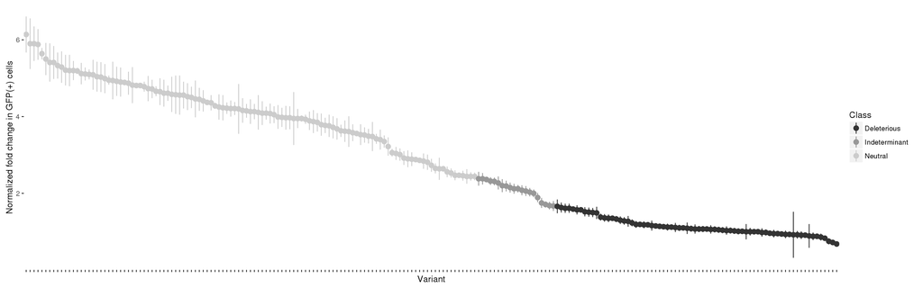

```r
functional_data <-read.csv("./sources/functional_activity_scores.tsv",header=T,sep="\t")

lev<- (functional_data$Variant[order(functional_data$Fold,decreasing = T)])
functional_data$Variant<- factor(functional_data$Variant,lev)
functional_data<-functional_data[order(functional_data$Fold,decreasing = T),]

#Manually add lines
line1 <- which(functional_data$Fold<1.66)
line1 = functional_data$Variant[line1[1]]
line2 <- which(functional_data$Fold>2.41)
line2 <- functional_data$Variant[tail(line2,n=1)]

#Set status
functional_data$Class<-"Deleterious"
functional_data$Class[which(functional_data$Fold>1.66)]<-"Indeterminant"
functional_data$Class[which(functional_data$Fold>2.41)]<-"Neutral"

ggplot(functional_data,aes(x=Variant,y=Fold, ymin=MIN, ymax=MAX,order=Fold,colour=Class))+
  geom_pointrange()+
  theme(axis.text.x = element_blank(),panel.background = element_rect(fill="white"))+
  ylab("Normalized fold change in GFP(+) cells")+ scale_colour_grey()
```

```r
ggsave("figures/FIGURE_1.png",width=9,height=7, units="in",dpi = 600)
```

# Figure 3

### MCC values for optimized thresholds

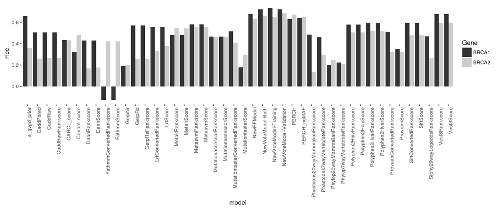

```r
ggplot(ST4,aes(x=model,y=mcc,fill=Gene))+ scale_colour_grey()+scale_fill_grey()+
  geom_bar(stat="identity",position="dodge")+
  theme(axis.text.x = element_text(angle = 90, hjust = 1),panel.background = element_rect(fill="white"))
```

```r
ggsave("figures/FIGURE_3.png",width=9,height=7, units="in",dpi = 600)
```

# Figure 5

### Estimates of the proportion of pathogenic missense mutations along each gene.

The x-axis is the amino acid position, and the y-axis is the probability of a missense mutation being damaging from the NVM model. The lines were smoothed using a 50 amino acid sliding window.

```r
BRCA1_All_missense <- all1..[which(all1..$CAVA_GENE=="BRCA1"),c("AAPOS","nvm_pred_del")]
BRCA2_All_missense <- all2..[which(all2..$CAVA_GENE=="BRCA2"),c("AAPOS","nvm_pred_del")]

# reorder BRCA1
BRCA1_All_missense <- BRCA1_All_missense[order(BRCA1_All_missense$AAPOS,decreasing = F),]

#Make curve
RES<-NULL
window=50

tmp <- BRCA1_All_missense
for (i in 1:length(tmp$AAPOS)){
  pos<-tmp$AAPOS[i]
  if(pos-window < 0){winMin = 0}else{winMin = pos-window}
  winMax<-pos+window
  events<-length(which(tmp$AAPOS>winMin & tmp$AAPOS<winMax))
  pevents<-length(which(tmp$AAPOS>winMin & tmp$AAPOS<winMax & tmp$nvm_pred_del==1))
  ratio<-pevents/events
  NUM<-c(pos,ratio)
  RES<-rbind(RES,NUM)
}

RES<-data.frame(RES)
names(RES)<-c("AAPOS","ProbPathMissense")


Domains = NULL
Domains = data.frame(
  name=c("RING","TP53 Interaction","PALB2 Interaction","BRCT","BRCT"),
  min_x_pos=c(24,224,1397,1642,1756),
  max_x_pos=c(65,500,1474,1736,1855),
  min_y_pos=c(-0.01,-0.01,-0.01,-0.01,-0.01),
  max_y_pos=c(0.01,0.01,0.01,0.01,0.01)
  )

b1 <- ggplot(data=RES,aes(x=AAPOS,y=ProbPathMissense))+
  geom_line()+
  ggtitle("BRCA1")+
  geom_rect(inherit.aes = FALSE,data=Domains,
            aes(xmin=min_x_pos,xmax=max_x_pos,ymin=min_y_pos,ymax=max_y_pos,fill=name))+
  theme_bw()+scale_fill_grey()
```

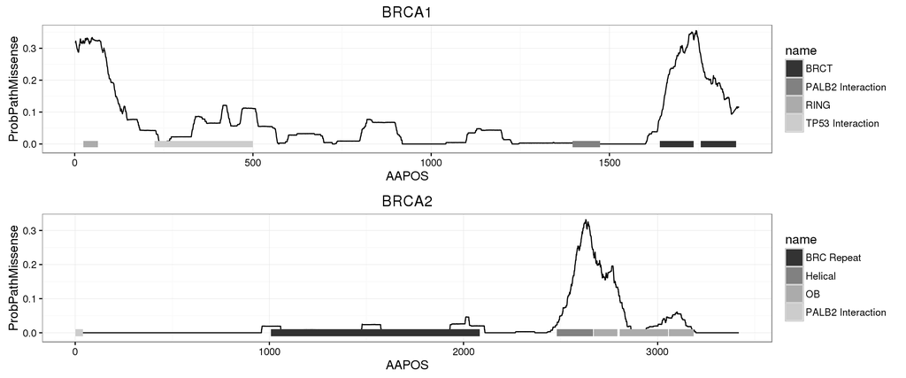

```r
#Make curve
RES<-NULL
window=50

tmp <- BRCA2_All_missense
for (i in 1:length(tmp$AAPOS)){
  pos<-tmp$AAPOS[i]
  if(pos-window < 0){winMin = 0}else{winMin = pos-window}
  winMax<-pos+window
  events<-length(which(tmp$AAPOS>winMin & tmp$AAPOS<winMax))
  pevents<-length(which(tmp$AAPOS>winMin & tmp$AAPOS<winMax & tmp$nvm_pred_del==1))
  ratio<-pevents/events
  NUM<-c(pos,ratio)
  RES<-rbind(RES,NUM)
}

RES<-data.frame(RES)
names(RES)<-c("AAPOS","ProbPathMissense")


Domains = NULL
Domains = data.frame(
  name=c("PALB2 Interaction","BRC Repeat","Helical","OB","OB","OB"),
  min_x_pos=c(1, 1009,2481,2670,2804,3057 ),
  max_x_pos=c(39,2083,2667,2793,3054,3186 ),
  min_y_pos=c(-0.01,-0.01,-0.01,-0.01,-0.01,-0.01),
  max_y_pos=c(0.01,0.01,0.01,0.01,0.01,0.01)
  )

b2<-ggplot(data=RES,aes(x=AAPOS,y=ProbPathMissense))+
  geom_line()+
  ggtitle("BRCA2")+
  geom_rect(inherit.aes = FALSE,data=Domains,
            aes(xmin=min_x_pos,xmax=max_x_pos,ymin=min_y_pos,ymax=max_y_pos,fill=name))+
  theme_bw()+scale_fill_grey()


FIGURE_5 = grid.arrange(b1,b2)
```

```r
ggsave("figures/FIGURE_5.png",width=9,height=7, units="in",plot = FIGURE_5,dpi = 600)
#grid.arrange(b1,b2)
```

# Table S5

Summary of vote model rules for functional class predictions.

BRCA1 - Scenario 1

```r
row="PERCH_noMAF>=0.206316"
row=rbind(row,"MetasvmRankscore >= 0.9083")
row=rbind(row,"MetalrRankscore >= 0.90291")
row=rbind(row,"MutationassessorRankscore >= 0.54432")
row=rbind(row,"Vest3Rankscore >= 0.85546")
row=rbind(row,"FathmmConvertedRankscore >= 0.88158")
row=rbind(row,"Polyphen2HvarRankscore >= 0.91584")
row=rbind(row,"MutationtasterConvertedRankscore >= 0.81033")
row=rbind(row,"SiftConvertedRankscore >= 0.91219")
df = data.frame(row)
names(df)<-"BRCA1 - Scenario 1"
kable(df,row.names = FALSE)
```

## BRCA1 - Scenario 1

PERCH_noMAF>=0.206316  
MetasvmRankscore >= 0.9083  
MetalrRankscore >= 0.90291  
MutationassessorRankscore >= 0.54432  
Vest3Rankscore >= 0.85546  
FathmmConvertedRankscore >= 0.88158  
Polyphen2HvarRankscore >= 0.91584  
MutationtasterConvertedRankscore >= 0.81033 SiftConvertedRankscore >= 0.91219

```r
row="PERCH_noMAF >= 0.140337"
row=rbind(row,"MetasvmRankscore >= 0.8874")
row=rbind(row,"MetalrRankscore >= 0.89743")
row=rbind(row,"MutationassessorRankscore >= 0.44691")
row=rbind(row,"Vest3Rankscore >= 0.80056")
row=rbind(row,"FathmmConvertedRankscore >=0.88313")
df = data.frame(row)
names(df)<-"BRCA1 - Scenario 2"
kable(df,row.names = FALSE)
```

## BRCA1 - Scenario 2

PERCH_noMAF >= 0.140337  
MetasvmRankscore >= 0.8874  
MetalrRankscore >= 0.89743  
MutationassessorRankscore >= 0.44691 Vest3Rankscore >= 0.80056  
FathmmConvertedRankscore >=0.88313

```r
row="PERCH>=0.295957"
row=rbind(row,"MetasvmRankscore >= 0.93181")
row=rbind(row,"MetalrRankscore >= 0.92107")
row=rbind(row,"MutationassessorRankscore >= 0.84368")
row=rbind(row,"Vest3Rankscore >= 0.79963")
row=rbind(row,"Polyphen2HvarRankscore >= 0.97092")
df = data.frame(row)
names(df)<-"BRCA1 - Scenario 1"
kable(df,row.names = FALSE)
```

PERCH>=0.295957  
MetasvmRankscore >= 0.93181  
MetalrRankscore >= 0.92107  
MutationassessorRankscore >= 0.84368 Vest3Rankscore >= 0.79963  
Polyphen2HvarRankscore >= 0.97092

```r
row="PERCH >= 0.232796"
row=rbind(row,"MetasvmRankscore >= 0.92233")
row=rbind(row,"MetalrRankscore >= 0.91514")
row=rbind(row,"MutationassessorRankscore >= 0.83541")
row=rbind(row,"Vest3Rankscore >= 0.7831")
df = data.frame(row)
names(df)<-"BRCA2 - Scenario 2"
kable(df,row.names = FALSE)
```

## BRCA2 - Scenario 2

PERCH >= 0.232796  
MetasvmRankscore >= 0.92233  
MetalrRankscore >= 0.91514  
MutationassessorRankscore >= 0.83541 Vest3Rankscore >= 0.7831